# A2 - Predicting Car Prices

# Filling the missing numerical values

Using the obtained median and mean of test and train dataset to fill in the null values.

```python
X_train['max_power'].fillna(X_train['max_power'].median(), inplace=True)
X_train['mileage'].fillna(X_train['mileage'].mean(), inplace=True)
X_test['max_power'].fillna(X_test['max_power'].median(), inplace=True)
X_test['mileage'].fillna(X_test['mileage'].mean(), inplace=True)
```

```python
#Verifying if the null values are filled in training set
X_train[['max_power', 'mileage', 'brand', 'year']].isnull().sum()
```

```
max_power    0
mileage      0
brand        0
year         0
dtype: int64
```

```python
#Verifying if the null values are filled in test set
X_test[['max_power', 'mileage', 'brand', 'year']].isnull().sum()
```

```
max_power    0
mileage      0
brand        0
year         0
dtype: int64
```

```python
#Verifying if the null values are filled in y_train and y_test
y_train.isnull().sum(), y_test.isnull().sum()
```

```
(np.int64(0), np.int64(0))
```

# Checking for outliers

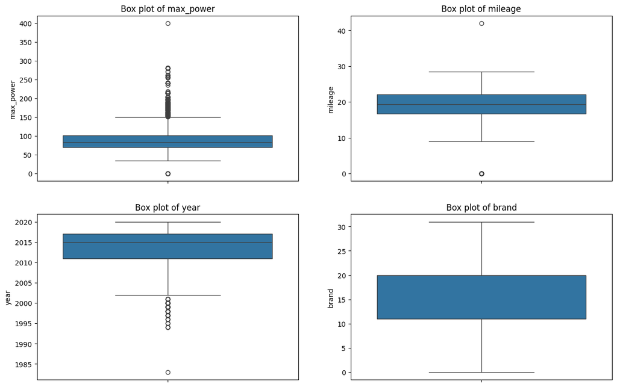

```python
#Checking the outliers in the training set using box plot
#Creating a dictionary to store the columns and their respective values

col_dict = {'max_power': 1, 'mileage': 2, 'year': 3, 'brand': 4}

#Using boxplot to visualize the outliers in the training set
plt.figure(figsize=(15,20))
for i, col in col_dict.items():
    plt.subplot(4,2,col)
    sns.boxplot(X_train[i])
    plt.title(f'Box plot of {i}')
plt.show()
```

```python
#To check the impact of outliers on the efficiency of the model, we will define a function to calculate the outliers of each feature using the IQR method

def calculate_outliers(col, data=X_train):
    q75 = np.percentile(data[col], 75)
    q25 = np.percentile(data[col], 25)
    iqr = q75 - q25
    min_val = q25 - (1.5 * iqr)
    max_val = q75 + (1.5 * iqr)

    calculate_outliers = len(np.where((data[col] < min_val) | (data[col] > max_val))[0])
    percentage_outliers = round(calculate_outliers / len(data) * 100, 2)

    if calculate_outliers > 0:
        print(f'Feature {col} has {calculate_outliers} outliers which is {percentage_outliers}% of the data')
    else:
        print(f'Feature {col} has no outliers')
```

```python
for col in X_train.columns:
    calculate_outliers(col)
```

```
Feature max_power has 412 outliers which is 7.33% of the data
Feature mileage has 13 outliers which is 0.23% of the data
Feature year has 55 outliers which is 0.98% of the data
Feature brand has no outliers
```

Since the percentage of the outliers are low in the dataset, we are neglecting them for analysis

# Scaling the dataset

```python
#Importing the library from sklearn for scaling the features, excluding the categorical features

from sklearn.preprocessing import MinMaxScaler
num_cols = ['max_power', 'mileage', 'year']
scaler = MinMaxScaler()
X_train[num_cols] = scaler.fit_transform(X_train[num_cols])
X_test[num_cols] = scaler.transform(X_test[num_cols])
```

```python
#Verifying the changes made
print(X_train.shape)
print(X_test.shape)
print(y_train.shape)
print(y_test.shape)
```

```
(5623, 4)
(2410, 4)
(5623,)
(2410,)
```

Configure MLflow for experiment tracking in a Dockerized setup, and setting the experiment name and overriding the default user ID.

```python
#experiment tracking
import mlflow
import os
# This the dockerized method.
# We build two docker containers, one for python/jupyter and another for mlflow.
# The url `mlflow` is resolved into another container within the same composer.
#mlflow.set_tracking_uri("http://localhost:5000")
# In the dockerized way, the user who runs this code will be `root`.
# The MLflow will also log the run user_id as `root`.
# To change that, we need to set this environ["LOGNAME"] to your name.
os.environ["LOGNAME"] = "anushka"
# mlflow.create_experiment(name="chaky-diabetes-example")  #create if you haven't create
mlflow.set_experiment(experiment_name="anushka-regularization-example")
```

```
<Experiment: artifact_location='file:///Projects/Python-for-Machine-Learning/A2/mlruns/368821136563494397', creation_time=1757217537954, experiment_id='368821136563494397', last_update_time=1757217537954, lifecycle_stage='active', name='anushka-regularization-example', tags={}>
```

Creating a linear regression class

```python
from sklearn.model_selection import KFold

class LinearRegression(object):

    #in this class, we add cross validation as well for some spicy code....
    kfold = KFold(n_splits=3)

    def __init__(self, regularization, lr=0.01, method='batch', init='xavier', polynomial=True, degree=2, use_momentum=True, momentum=0.5, num_epochs=500, batch_size=50, cv=kfold):


        # Initialize hyperparameters and options
        self.lr         = lr
        self.num_epochs = num_epochs
        self.batch_size = batch_size
        self.method     = method
        self.polynomial = polynomial
        self.degree     = degree
        self.init       = init
        self.use_momentum   = use_momentum
        self.momentum   = momentum
        self.prev_step  = 0
        self.cv         = cv
        self.regularization = regularization

    def mse(self, ytrue, ypred):
        return ((ypred - ytrue) ** 2).sum() / ytrue.shape[0]

    def r2(self, ytrue, ypred):
        return 1 - (((ytrue - ypred) ** 2).sum() / ((ytrue - ytrue.mean()) ** 2).sum())

    # function to compute average mse for all kfold_scores
    def avgMse(self):
        return np.sum(np.array(self.kfold_scores))/len(self.kfold_scores)

    # function to compute average r2 for all kfold_scores
    def avgr2(self):
        return np.sum(np.array(self.kfold_r2))/len(self.kfold_r2)

    def fit(self, X_train, y_train):

        # Store column names for later use

        self.columns = X_train.columns

        if self.polynomial == True:
            X_train = self._transform_features(X_train)
            print("Using Polynomial")
        else:
            print("Using Linear")
            X_train = X_train.to_numpy()

        y_train = y_train.to_numpy()

        #create a list of kfold scores
        self.kfold_scores = list()
        self.kfold_r2 = list()

        #reset val loss
        self.val_loss_old = np.inf

        #X_train = np.c_[np.ones((X_train.shape[0],1)), X_train]
        # Perform k-fold cross-validation
        for fold, (train_idx, val_idx) in enumerate(self.cv.split(X_train)):

            X_cross_train = X_train[train_idx]
            y_cross_train = y_train[train_idx]
            X_cross_val   = X_train[val_idx]
            y_cross_val   = y_train[val_idx]

            #initialize weights using Xavier method
            if self.init == 'xavier':
                #calculate the range for the weights with number of samples
                n_features = X_cross_train.shape[1]
                lower, upper = -(1 / np.sqrt(n_features)), 1 / np.sqrt(n_features)
                #randomize weights then scale them using lower and upper bounds
                self.theta = np.random.rand(X_cross_train.shape[1])
                self.theta = lower + self.theta * (upper - lower)

            #initialize weights with zero
            elif self.init == 'zero':
                self.theta = np.zeros(X_cross_train.shape[1])

            else:
                print("Wrong weights init method. Must be either 'xavier' or 'zero'")
                return
            # Start training for the current fold
            with mlflow.start_run(run_name=f"Fold-{fold}", nested=True):

                params = {
                    "method": self.method,
                    "lr": self.lr,
                    "reg": type(self).__name__
                }

                mlflow.log_params(params=params)

                for epoch in range(self.num_epochs):
                    perm = np.random.permutation(X_cross_train.shape[0])

                    X_cross_train = X_cross_train[perm]
                    y_cross_train = y_cross_train[perm]
                    if self.method == 'sto':
                        for batch_idx in range(X_cross_train.shape[0]):
                            X_method_train = X_cross_train[batch_idx].reshape(1, -1)
                            y_method_train = y_cross_train[batch_idx].reshape(1, )
                            train_loss = self._train(X_method_train, y_method_train)
                    elif self.method == 'mini':
                        for batch_idx in range(0, X_cross_train.shape[0], self.batch_size):
                            X_method_train = X_cross_train[batch_idx:batch_idx+self.batch_size, :]
                            y_method_train = y_cross_train[batch_idx:batch_idx+self.batch_size]
                            train_loss = self._train(X_method_train, y_method_train)
                    else:
                        X_method_train = X_cross_train
                        y_method_train = y_cross_train
                        train_loss = self._train(X_method_train, y_method_train)
                    mlflow.log_metric(key="train_loss", value=train_loss, step=epoch)
                    yhat_val = self._predict(X_cross_val)
                    val_loss_new = self.mse(y_cross_val, yhat_val)
                    val_r2_new = self.r2(y_cross_val, yhat_val)
                    mlflow.log_metric(key="val_loss", value=val_loss_new, step=epoch)
                    mlflow.log_metric(key="val_r2", value=val_r2_new, step=epoch)

                    if np.allclose(val_loss_new, self.val_loss_old):
                        break
                    self.val_loss_old = val_loss_new
                self.kfold_scores.append(val_loss_new)
                self.kfold_r2.append(val_r2_new)

                print(f"Fold {fold}: MSE {val_loss_new}")
                print(f"Fold {fold}: R2: {val_r2_new}")

    def _transform_features(self, X):
        X = X.to_numpy() if hasattr(X, 'to_numpy') else X
        features = [np.ones((X.shape[0], 1))]  # Bias term
        feature_names = ["bias"]
        orig_cols = self.columns if hasattr(self, 'columns') and self.columns is not None else [f"x{i}" for i in range(X.shape[1])]

        # Adding original features
        features.append(X)
        feature_names.extend(orig_cols)

        # Adding polynomial features
        for d in range(2, self.degree + 1):
            features.append(X ** d)
            feature_names.extend([f"{col}^{d}" for col in orig_cols])

        X_poly = np.hstack(features)
        self.poly_feature_names = feature_names
        return X_poly


    def _train(self, X, y):
        yhat = self._predict(X)
        m    = X.shape[0]
        if self.regularization:
            # If regularization is enabled, compute the gradient with regularization term
            grad = (1/m) * X.T @(yhat - y) + self.regularization.derivation(self.theta)
        else:
            # If no regularization, compute the gradient without regularization term
            grad = (1/m) * X.T @(yhat - y)

        if self.use_momentum == True:
            self.step = self.lr * grad
            self.theta = self.theta - self.step + self.momentum * self.prev_step
            self.prev_step = self.step
        else:
            self.theta = self.theta - self.lr * grad
        return self.mse(y, yhat)

    def _predict(self, X):
        return X @ self.theta   # Matrix multiplication of input features and model weights to make predictions

    def predict(self, X):
        if self.polynomial == True:
            X = self._transform_features(X)
        return X @ self.theta  # Matrix multiplication of input features and model weights to make predictions

    def _coef(self):
        return self.theta[1:] # Return all weights except the first one (bias term)
    def _bias(self):
        return self.theta[0] # Return the first weight, which represents the bias term

    def feature_importance(self, width=5, height=10):
        if self.theta is not None:
            index_names = getattr(self, 'poly_feature_names',
                             self.columns if hasattr(self, 'columns') and self.columns is not None else None)
            if index_names is None:
                print("Feature names are not available.")
                return

            if len(self.theta) != len(index_names):
                raise ValueError(
                    f"Mismatch: theta has {len(self.theta)} elements, "
                    f"but feature names has {len(index_names)} names."
                )

            coefs = pd.DataFrame(data=self.theta, columns=['Coefficients'], index=index_names)
            coefs.plot(kind="barh", figsize=(width, height))
            plt.title("Feature Importance")
            plt.show()
        else:
            print("Coefficients are not available to create the graph.")
```

```python
class LassoPenalty:
    def __init__(self, l):
        self.l = l  # Lambda value for regularization

    def __call__(self, theta):
        return self.l * np.sum(np.abs(theta))

    def derivation(self, theta):
        return self.l * np.sign(theta)

# Define a class for Ridge (L2) regularization penalty
class RidgePenalty:
    def __init__(self, l):
        self.l = l  # Lambda value for regularization

    def __call__(self, theta):
        return self.l * np.sum(np.square(theta))

    def derivation(self, theta):
        return self.l * 2 * theta

# Define a class for Elastic Net regularization penalty
class ElasticPenalty:
    def __init__(self, l=0.1, l_ratio=0.5):
        self.l = l  # Total regularization strength
        self.l_ratio = l_ratio  # Ratio between L1 and L2 regularization

    def __call__(self, theta):
        l1_contribution = self.l_ratio * self.l * np.sum(np.abs(theta))
        l2_contribution = (1 - self.l_ratio) * self.l * 0.5 * np.sum(np.square(theta))
        return (l1_contribution + l2_contribution)

    def derivation(self, theta):
        l1_derivation = self.l * self.l_ratio * np.sign(theta)
        l2_derivation = self.l * (1 - self.l_ratio) * theta
        return (l1_derivation + l2_derivation)

# Define classes for Lasso, Ridge, ElasticNet, and Normal (No Regularization) linear regression
class Lasso(LinearRegression):
    def __init__(self, l, lr, method, init, polynomial, degree, use_momentum, momentum):
        self.regularization = LassoPenalty(l)
        super().__init__(self.regularization, lr, method, init, polynomial, degree, use_momentum, momentum)
    def avgMSE(self):
        return np.sum(np.array(self.kfold_scores)) / len(self.kfold_scores)

class Ridge(LinearRegression):
    def __init__(self, l, lr, method, init, polynomial, degree, use_momentum, momentum):
        self.regularization = RidgePenalty(l)
        super().__init__(self.regularization, lr, method, init, polynomial, degree, use_momentum, momentum)
    def avgMSE(self):
        return np.sum(np.array(self.kfold_scores)) / len(self.kfold_scores)

class ElasticNet(LinearRegression):
    def __init__(self, l, lr, method, init, polynomial, degree, use_momentum, momentum, l_ratio=0.5):
        self.regularization = ElasticPenalty(l, l_ratio)
        super().__init__(self.regularization, lr, method, init, polynomial, degree, use_momentum, momentum)
    def avgMSE(self):
        return np.sum(np.array(self.kfold_scores)) / len(self.kfold_scores)

class Normal(LinearRegression):
    def __init__(self, l, lr, method, init, polynomial, degree, use_momentum, momentum):
        self.regularization = None  # No regularization
        super().__init__(self.regularization, lr, method, init, polynomial, degree, use_momentum, momentum)
    def avgMSE(self):
        return np.sum(np.array(self.kfold_scores)) / len(self.kfold_scores)
```

# Experiment

```python
#helper function for looping classnames
import sys

def str_to_class(classname):
    return getattr(sys.modules[__name__], classname)
```

Looping through all regression methdods

```python
regs = ["Ridge", "Lasso", "ElasticNet"]

# Looping through all regression methods
for reg in regs:
    params = {"method": "batch", "l": 0.1, "lr": 0.01,  "polynomial": True, "init" :"xavier", "use_momentum" :True,  "momentum":0.5, "degree":2}
    mlflow.start_run(run_name=f"method-{params['method']}-lr-{params['lr']}-reg-{reg}", nested=True)

    print("="*5, reg, "="*5)
    type_of_regression = str_to_class(reg)    #Ridge, Lasso, ElasticNet
    model = type_of_regression(**params)
    model.fit(X_train, y_train)
    mse = model.avgMSE()
    r2 = model.avgr2()

    #Predicting using the model
    yhat = model.predict(X_train)

    print("Test MSE: ", mse)
    print("Test R2: ", r2)
    # Logging the metrics in ml flow
    mlflow.log_metric(key="test_mse", value=mse)
    mlflow.log_metric(key="test_r2", value=r2)

    signature = mlflow.models.infer_signature(X_train, model.predict(X_train))
    mlflow.sklearn.log_model(model, artifact_path='model', signature=signature)


    mlflow.end_run()
```

```
===== Ridge =====
Using Polynomial
Fold 0: MSE 15.225598808210824
Fold 0: R2: -19.96031673182778
Fold 1: MSE 13.0192821083375
Fold 1: R2: -17.838351096296673
```

```
2025/09/11 06:14:15 WARNING mlflow.models.model: `artifact_path` is deprecated. Please use `name` instead.
```

```
Fold 2: MSE 14.707521001270806
Fold 2: R2: -20.025257489167966
Test MSE:  14.31746730593971
Test R2:  -19.274641772430808
```

```
2025/09/11 06:14:20 WARNING mlflow.utils.environment: Failed to resolve installed pip version. ``pip`` will be added to conda.yaml environment spec without a version specifier.
```

```
===== Lasso =====
Using Polynomial
Fold 0: MSE 10.38036998881748
Fold 0: R2: -13.290133708359647
Fold 1: MSE 8.50166457190145
Fold 1: R2: -11.301549407694464
```

```
2025/09/11 06:16:16 WARNING mlflow.models.model: `artifact_path` is deprecated. Please use `name` instead.
```

```
Fold 2: MSE 10.862791473937362
Fold 2: R2: -14.528992803813582
Test MSE:  9.914942011552098
Test R2:  -13.040225306622565
```

```
2025/09/11 06:16:21 WARNING mlflow.utils.environment: Failed to resolve installed pip version. ``pip`` will be added to conda.yaml environment spec without a version specifier.
```

```
===== ElasticNet =====
Using Polynomial
Fold 0: MSE 12.107482167702125
Fold 0: R2: -15.667762250712748
Fold 1: MSE 9.638540307099646
Fold 1: R2: -12.946560559177904
```

```
2025/09/11 06:18:17 WARNING mlflow.models.model: `artifact_path` is deprecated. Please use `name` instead.
```

```
Fold 2: MSE 11.774627796958365
Fold 2: R2: -15.83251591133362
Test MSE:  11.17355009058671
Test R2:  -14.815612907074756
```

```
2025/09/11 06:18:22 WARNING mlflow.utils.environment: Failed to resolve installed pip version. ``pip`` will be added to conda.yaml environment spec without a version specifier.
```

Looping through all regression methods and for each method checking the output with polynomial true or false

```python
# Settting up the experiment of polynomial and regularization type all others are hard quoted
regs = ["Ridge", "Lasso", "ElasticNet","Normal"]
ispoly= [True, False]

for reg in regs:
    for t in ispoly:

        params = {"method": "batch","polynomial": t,  "l": 0.1, "lr": 0.01, "init" :"xavier",
        "degree":2, "use_momentum" :True,  "momentum":0.5}
        mlflow.start_run(run_name=f"method-{params['method']}-lr-{params['lr']}-reg-{reg}-poly-{t}", nested=True)

        print("="*5, reg, "="*5)

        type_of_regression = str_to_class(reg)
        model = type_of_regression(**params)
        model.fit(X_train, y_train)
        yhat = model.predict(X_train)
        mse = model.avgMSE()
        r2 = model.avgr2()


        print("Test MSE: ", mse)
        print("Test R2: ", r2)

        mlflow.log_metric(key="test_mse", value=mse)
        mlflow.log_metric(key="test_r2", value=r2)

        signature = mlflow.models.infer_signature(X_train, model.predict(X_train))
        mlflow.sklearn.log_model(model, artifact_path='model', signature=signature)

    mlflow.end_run()
```

```
===== Ridge =====
Using Polynomial
Fold 0: MSE 15.895259687645124
Fold 0: R2: -20.882205211398635
Fold 1: MSE 12.869400355505807
Fold 1: R2: -17.621478533026572
```

```
2025/09/11 06:34:31 WARNING mlflow.models.model: `artifact_path` is deprecated. Please use `name` instead.
```

```
Fold 2: MSE 15.180456372176275
Fold 2: R2: -20.701346134437518
Test MSE:  14.648372138442403
Test R2:  -19.735009959620907
```

```
2025/09/11 06:34:36 WARNING mlflow.utils.environment: Failed to resolve installed pip version. ``pip`` will be added to conda.yaml environment spec without a version specifier.
```

```
===== Ridge =====
Using Linear
Fold 0: MSE 168.4104693451718
Fold 0: R2: -230.8422298456307
Fold 1: MSE 169.13959322771768
Fold 1: R2: -243.73784460573657
```

```
2025/09/11 06:34:54 WARNING mlflow.models.model: `artifact_path` is deprecated. Please use `name` instead.
```

```
Fold 2: MSE 169.3166577681884
Fold 2: R2: -241.04801927353338
Test MSE:  168.95557344702596
Test R2:  -238.54269790830025
```

```
2025/09/11 06:34:58 WARNING mlflow.utils.environment: Failed to resolve installed pip version. ``pip`` will be added to conda.yaml environment spec without a version specifier.
```

```
===== Lasso =====
Using Polynomial
Fold 0: MSE 10.531555626950171
Fold 0: R2: -13.498263378691943
Fold 1: MSE 9.09924113358229
Fold 1: R2: -12.166217442551183
```

```
2025/09/11 06:36:55 WARNING mlflow.models.model: `artifact_path` is deprecated. Please use `name` instead.
```

```
Fold 2: MSE 10.649001878475472
Fold 2: R2: -14.22336813105582
Test MSE:  10.093266213002645
Test R2:  -13.295949650766316
```

```
2025/09/11 06:37:00 WARNING mlflow.utils.environment: Failed to resolve installed pip version. ``pip`` will be added to conda.yaml environment spec without a version specifier.
```

```
===== Lasso =====
Using Linear
Fold 0: MSE 168.6094727071441
Fold 0: R2: -231.11618777334047
Fold 1: MSE 168.99210424338423
Fold 1: R2: -243.5244342773798
```

```
2025/09/11 06:37:19 WARNING mlflow.models.model: `artifact_path` is deprecated. Please use `name` instead.
```

```
Fold 2: MSE 169.39325901247918
Fold 2: R2: -241.1575252116901
Test MSE:  168.99827865433585
Test R2:  -238.59938242080344
```

```
2025/09/11 06:37:23 WARNING mlflow.utils.environment: Failed to resolve installed pip version. ``pip`` will be added to conda.yaml environment spec without a version specifier.
```

```
===== ElasticNet =====
Using Polynomial
Fold 0: MSE 12.113780989409836
Fold 0: R2: -15.676433522016687
Fold 1: MSE 9.383438035355313
Fold 1: R2: -12.5774383510106
```

```
2025/09/11 06:39:23 WARNING mlflow.models.model: `artifact_path` is deprecated. Please use `name` instead.
```

```
Fold 2: MSE 11.199365254964887
Fold 2: R2: -15.01014461788171
Test MSE:  10.89886142657668
Test R2:  -14.421338830303
```

```
2025/09/11 06:39:28 WARNING mlflow.utils.environment: Failed to resolve installed pip version. ``pip`` will be added to conda.yaml environment spec without a version specifier.
```

```
===== ElasticNet =====
Using Linear
Fold 0: MSE 168.55150518651706
Fold 0: R2: -231.03638680079374
Fold 1: MSE 169.05101849515987
Fold 1: R2: -243.60968071034665
```

```
2025/09/11 06:39:56 WARNING mlflow.models.model: `artifact_path` is deprecated. Please use `name` instead.
```

```
Fold 2: MSE 169.39315937933026
Fold 2: R2: -241.15738278030346
Test MSE:  168.99856102033573
Test R2:  -238.60115009714795
```

```
2025/09/11 06:40:02 WARNING mlflow.utils.environment: Failed to resolve installed pip version. ``pip`` will be added to conda.yaml environment spec without a version specifier.
```

```
===== Normal =====
Using Polynomial
Fold 0: MSE 10.08595822244985
Fold 0: R2: -12.884831824973983
Fold 1: MSE 9.014296071094375
Fold 1: R2: -12.043305526384975
```

```
2025/09/11 06:42:10 WARNING mlflow.models.model: `artifact_path` is deprecated. Please use `name` instead.
```

```
Fold 2: MSE 10.620793754327588
Fold 2: R2: -14.18304297541304
Test MSE:  9.90701601595727
Test R2:  -13.037060108923997
```

```
2025/09/11 06:42:15 WARNING mlflow.utils.environment: Failed to resolve installed pip version. ``pip`` will be added to conda.yaml environment spec without a version specifier.
```

```
===== Normal =====
Using Linear
Fold 0: MSE 168.74434215905802
Fold 0: R2: -231.3018557700592
Fold 1: MSE 169.12831512775585
Fold 1: R2: -243.72152567163468
```

```
2025/09/11 06:42:58 WARNING mlflow.models.model: `artifact_path` is deprecated. Please use `name` instead.
```

```
Fold 2: MSE 169.30993953074275
Fold 2: R2: -241.03841516199373
Test MSE:  169.0608656058522
Test R2:  -238.68726553456256
```

```
2025/09/11 06:43:03 WARNING mlflow.utils.environment: Failed to resolve installed pip version. ``pip`` will be added to conda.yaml environment spec without a version specifier.
```

Normal with polynomial features was found to be best. So testing it with other methods here.

```python
reg = "Normal"
ispoly= True
# Only testing with the method here
methods=["mini","batch","sto"]

for method in methods:
    params = {"method": method,"polynomial": ispoly,  "l": 0.1, "lr": 0.01, "init" :"xavier",
    "degree":2, "use_momentum" :True,  "momentum":0.5}
    mlflow.start_run(run_name=f"method-{params['method']}-lr-{params['lr']}-reg-{reg}-poly-{t}", nested=True)

    print("="*5, reg, "="*5)
    print("Method: ", method)

    type_of_regression = str_to_class(reg)
    model = type_of_regression(**params)
    model.fit(X_train, y_train)
    yhat = model.predict(X_train)
    mse = model.avgMSE()
    r2 = model.avgr2()

    print("Test MSE: ", mse)
    print("Test R2: ", r2)

    mlflow.log_metric(key="test_mse", value=mse)
    mlflow.log_metric(key="test_r2", value=r2)

    signature = mlflow.models.infer_signature(X_train, model.predict(X_train))
    mlflow.sklearn.log_model(model, artifact_path='model', signature=signature)

    mlflow.end_run()
```

```
===== Normal =====
Method:  mini
Using Polynomial
Fold 0: MSE 0.11197052804466119
Fold 0: R2: 0.8458558010092547
Fold 1: MSE 0.1184885680055888
Fold 1: R2: 0.8285520486911286
```

```
2025/09/11 06:44:45 WARNING mlflow.models.model: `artifact_path` is deprecated. Please use `name` instead.
```

```
Fold 2: MSE 0.11125773193379787
Fold 2: R2: 0.8409505951841371
Test MSE:  0.11390560932801597
Test R2:  0.8384528149615068
```

```
2025/09/11 06:44:51 WARNING mlflow.utils.environment: Failed to resolve installed pip version. ``pip`` will be added to conda.yaml environment spec without a version specifier.
```

```
===== Normal =====
Method:  batch
Using Polynomial
Fold 0: MSE 10.682273961214127
Fold 0: R2: -13.705749735272047
Fold 1: MSE 8.611067552556523
Fold 1: R2: -11.459850898007957
```

```
2025/09/11 06:47:01 WARNING mlflow.models.model: `artifact_path` is deprecated. Please use `name` instead.
```

```
Fold 2: MSE 10.7269432781625
Fold 2: R2: -14.334789899370435
Test MSE:  10.00676159731105
Test R2:  -13.166796844216814
```

```
2025/09/11 06:47:07 WARNING mlflow.utils.environment: Failed to resolve installed pip version. ``pip`` will be added to conda.yaml environment spec without a version specifier.
```

```
===== Normal =====
Method:  sto
Using Polynomial
Fold 0: MSE 0.11461868022270306
Fold 0: R2: 0.8422102229860177
Fold 1: MSE 0.13539223038624038
Fold 1: R2: 0.8040931634707178
```

```
2025/09/11 06:50:12 WARNING mlflow.models.model: `artifact_path` is deprecated. Please use `name` instead.
```

```
Fold 2: MSE 0.11230156792355203
Fold 2: R2: 0.8394583708684862
Test MSE:  0.1207708261774985
Test R2:  0.8285872524417406
```

```
2025/09/11 06:50:18 WARNING mlflow.utils.environment: Failed to resolve installed pip version. ``pip`` will be added to conda.yaml environment spec without a version specifier.
```

Testing normal with mini-batch method with polynomial features

```python
reg = "Normal"
ispoly= True
method="mini"
# Only testing with/without momentum here
momentums =[True, False]

for momentum in momentums:
    params = {"method": method,"polynomial": ispoly,  "l": 0.1, "lr": 0.01, "init" :"xavier",
    "degree":2, "use_momentum" :momentum,  "momentum":0.5}
    mlflow.start_run(run_name=f"method-{params['method']}-lr-{params['lr']}-reg-{reg}-poly-{ispoly}-momentum-{momentum}", nested=True)
    print("="*5, reg, "="*5)
    print("Method: ", method)
    print("Momentum: ", momentum)
    print("Inititalization: ", "Xavier")
    print("Learning Rate: ", "0.01")
    print("="*10)

    type_of_regression = str_to_class(reg)
    model = type_of_regression(**params)
    model.fit(X_train, y_train)
    yhat = model.predict(X_train)
    mse = model.avgMSE()
    r2 = model.avgr2()

    print("Test MSE: ", mse)
    print("Test R2: ", r2)

    mlflow.log_metric(key="test_mse", value=mse)
    mlflow.log_metric(key="test_r2", value=r2)

    signature = mlflow.models.infer_signature(X_train, model.predict(X_train))
    mlflow.sklearn.log_model(model, artifact_path='model', signature=signature)

    mlflow.end_run()
```

```
===== Normal =====
Method:  mini
Momentum:  True
Inititalization:  Xavier
Learning Rate:  0.01
==========
Using Polynomial
Fold 0: MSE 0.11146255383590982
Fold 0: R2: 0.8465551035747003
Fold 1: MSE 0.11898121566469856
Fold 1: R2: 0.8278392083446449
```

```
2025/09/11 06:56:57 WARNING mlflow.models.model: `artifact_path` is deprecated. Please use `name` instead.
```

```
Fold 2: MSE 0.11465431447736231
Fold 2: R2: 0.8360949827015518
Test MSE:  0.11503269465932357
Test R2:  0.8368297648736324
```

```
2025/09/11 06:57:02 WARNING mlflow.utils.environment: Failed to resolve installed pip version. ``pip`` will be added to conda.yaml environment spec without a version specifier.
```

```
===== Normal =====
Method:  mini
Momentum:  False
Inititalization:  Xavier
Learning Rate:  0.01
==========
Using Polynomial
Fold 0: MSE 0.11154738773932482
Fold 0: R2: 0.846438317003113
Fold 1: MSE 0.11905638709261655
Fold 1: R2: 0.8277304384647278
```

```
2025/09/11 06:58:14 WARNING mlflow.models.model: `artifact_path` is deprecated. Please use `name` instead.
```

```
Fold 2: MSE 0.11214946826398049
Fold 2: R2: 0.8396758061865273
Test MSE:  0.11425108103197396
Test R2:  0.8379481872181227
```

```
2025/09/11 06:58:20 WARNING mlflow.utils.environment: Failed to resolve installed pip version. ``pip`` will be added to conda.yaml environment spec without a version specifier.
```

Testing the conditions with different theta initializations

```python
#Testing

reg = "Normal"
ispoly= True
method="mini"
momentum =False
# Only testing diff initialization here
inits=["zero",'xavier']

for init in inits:
    params = {"method": method,"polynomial": ispoly,  "l": 0.1, "lr": 0.01, "init" :init,
    "degree":2, "use_momentum" :momentum,  "momentum":0.5}
    mlflow.start_run(run_name=f"method-{params['method']}-lr-{params['lr']}-reg-{reg}-poly-{t}-momentum-{momentum}-init-{init}", nested=True)

    print("="*5, reg, "="*5)
    print("Method: ", method)
    print("Momentum: ", momentum)
    print("Inititalization: ", init)
    print("Learning Rate: ", "0.01")
    print("="*10)
    type_of_regression = str_to_class(reg)
    model = type_of_regression(**params)
    model.fit(X_train, y_train)
    yhat = model.predict(X_train)
    mse = model.avgMSE()
    r2 = model.avgr2()
    print("Test MSE: ", mse)
    print("Test R2: ", r2)
    mlflow.log_metric(key="test_mse", value=mse)
    mlflow.log_metric(key="test_r2", value=r2)
    signature = mlflow.models.infer_signature(X_train, model.predict(X_train))
    mlflow.sklearn.log_model(model, artifact_path='model', signature=signature)

    mlflow.end_run()
```

```
===== Normal =====
Method:  mini
Momentum:  False
Inititalization:  zero
Learning Rate:  0.01
==========
Using Polynomial
Fold 0: MSE 0.11148367331907238
Fold 0: R2: 0.8465260294435693
Fold 1: MSE 0.11927668886051314
Fold 1: R2: 0.8274116711151739
```

```
2025/09/11 07:02:31 WARNING mlflow.models.model: `artifact_path` is deprecated. Please use `name` instead.
```

```
Fold 2: MSE 0.1148817236617844
Fold 2: R2: 0.8357698880334931
Test MSE:  0.11521402861378997
Test R2:  0.836569196197412
```

```
2025/09/11 07:02:38 WARNING mlflow.utils.environment: Failed to resolve installed pip version. ``pip`` will be added to conda.yaml environment spec without a version specifier.
```

```
===== Normal =====
Method:  mini
Momentum:  False
Inititalization:  xavier
Learning Rate:  0.01
==========
Using Polynomial
Fold 0: MSE 0.11069839108376912
Fold 0: R2: 0.8476070880333277
Fold 1: MSE 0.11922792999827574
Fold 1: R2: 0.827482223128583
```

```
2025/09/11 07:04:36 WARNING mlflow.models.model: `artifact_path` is deprecated. Please use `name` instead.
```

```
Fold 2: MSE 0.11026034674442098
Fold 2: R2: 0.8423764153764537
Test MSE:  0.11339555594215528
Test R2:  0.8391552421794547
```

```
2025/09/11 07:04:41 WARNING mlflow.utils.environment: Failed to resolve installed pip version. ``pip`` will be added to conda.yaml environment spec without a version specifier.
```

Testing the best model with different learning rates

```python
reg = "Normal"
ispoly= True
method="mini"
momentum =False
init='xavier'
# Only testing diff learning rate here
lrs =[0.01,0.001,0.0001]

for lr in lrs:
    params = {"method": method,"polynomial": ispoly,  "l": 0.1, "lr": lr, "init" :init, "degree":2, "use_momentum" :momentum,  "momentum":0.5}
    mlflow.start_run(run_name=f"method-{params['method']}-lr-{params['lr']}-reg-{reg}-poly-{t}-momentum-{momentum}-init-{init}", nested=True)

    print("="*5, reg, "="*5)
    print("Method: ", method)
    print("Momentum: ", momentum)
    print("Inititalization: ", init)
    print("Learning Rate: ", lr)
    print("="*10)


    type_of_regression = str_to_class(reg)
    model = type_of_regression(**params)
    model.fit(X_train, y_train)
    yhat = model.predict(X_train)
    mse = model.avgMSE()
    r2 = model.avgr2()

    print("Test MSE: ", mse)
    print("Test R2: ", r2)

    mlflow.log_metric(key="test_mse", value=mse)
    mlflow.log_metric(key="test_r2", value=r2)

    signature = mlflow.models.infer_signature(X_train, model.predict(X_train))
    mlflow.sklearn.log_model(model, artifact_path='model', signature=signature)

    mlflow.end_run()
```

```
===== Normal =====
Method:  mini
Momentum:  False
Inititalization:  xavier
Learning Rate:  0.01
==========
Using Polynomial
Fold 0: MSE 0.11184453526273629
Fold 0: R2: 0.8460292489404878
Fold 1: MSE 0.11975716174867648
Fold 1: R2: 0.8267164471478188
```

```
2025/09/11 07:07:09 WARNING mlflow.models.model: `artifact_path` is deprecated. Please use `name` instead.
```

```
Fold 2: MSE 0.10972463965530009
Fold 2: R2: 0.843142239847251
Test MSE:  0.11377544555557095
Test R2:  0.8386293119785192
```

```
2025/09/11 07:07:13 WARNING mlflow.utils.environment: Failed to resolve installed pip version. ``pip`` will be added to conda.yaml environment spec without a version specifier.
```

```
===== Normal =====
Method:  mini
Momentum:  False
Inititalization:  xavier
Learning Rate:  0.001
==========
Using Polynomial
Fold 0: MSE 0.11274669188281772
Fold 0: R2: 0.844787295258612
Fold 1: MSE 0.11924386298330898
Fold 1: R2: 0.8274591687724694
```

```
2025/09/11 07:08:45 WARNING mlflow.models.model: `artifact_path` is deprecated. Please use `name` instead.
```

```
Fold 2: MSE 0.11149655434349633
Fold 2: R2: 0.8406091846461097
Test MSE:  0.11449570306987433
Test R2:  0.8376185495590637
```

```
2025/09/11 07:08:50 WARNING mlflow.utils.environment: Failed to resolve installed pip version. ``pip`` will be added to conda.yaml environment spec without a version specifier.
```

```
===== Normal =====
Method:  mini
Momentum:  False
Inititalization:  xavier
Learning Rate:  0.0001
==========
Using Polynomial
Fold 0: MSE 5.486460712583999
Fold 0: R2: -6.552934746347996
Fold 1: MSE 4.498107013729175
Fold 1: R2: -5.508570786639577
```

```
2025/09/11 07:10:49 WARNING mlflow.models.model: `artifact_path` is deprecated. Please use `name` instead.
```

```
Fold 2: MSE 5.371079718593041
Fold 2: R2: -6.678271142261766
Test MSE:  5.118549148302072
Test R2:  -6.246592225083114
```

```
2025/09/11 07:10:54 WARNING mlflow.utils.environment: Failed to resolve installed pip version. ``pip`` will be added to conda.yaml environment spec without a version specifier.
```

# Grid Search

This covers all regularization methods (Ridge, Lasso, ElasticNet, and Normal), testing both polynomial and linear features, and evaluating different training modes (stochastic, mini-batch, and full batch). It also explores learning rates of 0.01, 0.001, and 0.0001, as well as the effect of momentum on the model, with the goal of comparing the average MSE and R² across folds under different parameter settings.

```python
regs = ["Ridge", "Lasso", "ElasticNet","Normal"]
ispoly= [True, False]
lrs=[0.01,0.001,0.0001]
methods = ["sto","mini","batch"]
inits =['zero','xavier']
use_momentums =[True, False]
momentum =""
for reg in regs:
    print("="*5, reg, "="*5)
    for method in methods:
        print("="*5, method, "="*5)
        for t in ispoly:
            if t==True:
                print("Polynomial")
            else:
                print("Linear")
            for init in inits:
                print("="*5, init, "="*5)
                for use_momentum in use_momentums:
                    if(use_momentum== True):
                         momentum = "Momentum Used"
                    else:
                        momentum ="Momentum not used"
                    print("="*5, momentum, "="*5)
                    for lr in lrs:
                        print("="*5, lr, "="*5)
                        params = {"method": method,"polynomial": t,  "l": 0.1, "lr": lr, "init" :init,
                        "degree":2, "use_momentum" :use_momentum,  "momentum":0.5}
                        mlflow.start_run(run_name=f"method-{params['method']}-lr-{params['lr']}-reg-{reg}-poly-{t}-momentum-{momentum}-init-{init}", nested=True)
                        type_of_regression = str_to_class(reg)
                        model = type_of_regression(**params)
                        model.fit(X_train, y_train)
                        yhat = model.predict(X_train)
                        mse = model.avgMSE()
                        r2 = model.avgr2()

                        print("Test MSE: ", mse)
                        print("Test R2: ", r2)

                        mlflow.log_metric(key="test_mse", value=mse)
                        mlflow.log_metric(key="test_r2", value=r2)

                        signature = mlflow.models.infer_signature(X_train, model.predict(X_train))
                        mlflow.sklearn.log_model(model, artifact_path='model', signature=signature)


                        mlflow.end_run()
```

```
===== Ridge =====
===== sto =====
Polynomial
===== zero =====
===== Momentum Used =====
===== 0.01 =====
Using Polynomial
Fold 0: MSE 8.861428663552568
Fold 0: R2: -11.199083518764114
Fold 1: MSE 11.45200643777976
Fold 1: R2: -15.570569424391518
```

```
2025/09/10 07:22:17 WARNING mlflow.models.model: `artifact_path` is deprecated. Please use `name` instead.
```

```
Fold 2: MSE 6.843197668799786
Fold 2: R2: -8.78274945338222
Test MSE:  9.052210923377372
Test R2:  -11.850800798845952
```

```
2025/09/10 07:22:23 WARNING mlflow.utils.environment: Failed to resolve installed pip version. ``pip`` will be added to conda.yaml environment spec without a version specifier.
```

```
===== 0.001 =====
Using Polynomial
Fold 0: MSE 8.092412852947875
Fold 0: R2: -10.140418098434955
Fold 1: MSE 6.433761438396594
Fold 1: R2: -8.309380950330034
```

```
2025/09/10 07:24:59 WARNING mlflow.models.model: `artifact_path` is deprecated. Please use `name` instead.
```

```
Fold 2: MSE 8.356069112680132
Fold 2: R2: -10.945487256227795
Test MSE:  7.6274144680082
Test R2:  -9.798428768330927
```

```
2025/09/10 07:25:03 WARNING mlflow.utils.environment: Failed to resolve installed pip version. ``pip`` will be added to conda.yaml environment spec without a version specifier.
```

```
===== 0.0001 =====
Using Polynomial
Fold 0: MSE 8.177782336901217
Fold 0: R2: -10.257941976834388
Fold 1: MSE 6.6842899770549185
Fold 1: R2: -8.6718851599796
```

```
2025/09/10 07:27:37 WARNING mlflow.models.model: `artifact_path` is deprecated. Please use `name` instead.
```

```
Fold 2: MSE 7.67446084401069
Fold 2: R2: -9.971088555435001
Test MSE:  7.512177719322275
Test R2:  -9.633638564082998
```

```
2025/09/10 07:27:44 WARNING mlflow.utils.environment: Failed to resolve installed pip version. ``pip`` will be added to conda.yaml environment spec without a version specifier.
```

```
===== Momentum not used =====
===== 0.01 =====
Using Polynomial
Fold 0: MSE 17.466667093608045
Fold 0: R2: -23.04548281766003
Fold 1: MSE 175.21161731013396
Fold 1: R2: -252.52380688675
```

```
2025/09/10 07:30:28 WARNING mlflow.models.model: `artifact_path` is deprecated. Please use `name` instead.
```

```
Fold 2: MSE 9.199345625530425
Fold 2: R2: -12.151000123808476
Test MSE:  67.2925433430908
Test R2:  -95.90676327607285
```

```
2025/09/10 07:30:32 WARNING mlflow.utils.environment: Failed to resolve installed pip version. ``pip`` will be added to conda.yaml environment spec without a version specifier.
```

```
===== 0.001 =====
Using Polynomial
Fold 0: MSE 9.711143676703232
Fold 0: R2: -12.36884347577956
Fold 1: MSE 6.611610683418943
Fold 1: R2: -8.5667212930665
```

```
2025/09/10 07:33:05 WARNING mlflow.models.model: `artifact_path` is deprecated. Please use `name` instead.
```

```
Fold 2: MSE 7.828554175865141
Fold 2: R2: -10.19137394406873
Test MSE:  8.050436178662439
Test R2:  -10.375646237638263
```

```
2025/09/10 07:33:10 WARNING mlflow.utils.environment: Failed to resolve installed pip version. ``pip`` will be added to conda.yaml environment spec without a version specifier.
```

```
===== 0.0001 =====
Using Polynomial
Fold 0: MSE 8.162667082499663
Fold 0: R2: -10.237133565701955
Fold 1: MSE 6.537251649465055
Fold 1: R2: -8.45912691288883
```

```
2025/09/10 07:35:21 WARNING mlflow.models.model: `artifact_path` is deprecated. Please use `name` instead.
```

```
Fold 2: MSE 7.947418895379322
Fold 2: R2: -10.361297980481625
Test MSE:  7.549112542448014
Test R2:  -9.685852819690803
```

```
2025/09/10 07:35:27 WARNING mlflow.utils.environment: Failed to resolve installed pip version. ``pip`` will be added to conda.yaml environment spec without a version specifier.
```

```
===== xavier =====
===== Momentum Used =====
===== 0.01 =====
Using Polynomial
Fold 0: MSE 12.06124395956707
Fold 0: R2: -15.604108433228717
Fold 1: MSE 12.616846222208292
Fold 1: R2: -17.256043373523212
```

```
2025/09/10 07:38:26 WARNING mlflow.models.model: `artifact_path` is deprecated. Please use `name` instead.
```

```
Fold 2: MSE 9.84650584664465
Fold 2: R2: -13.076153335182289
Test MSE:  11.508198676140003
Test R2:  -15.312101713978073
```

```
2025/09/10 07:38:31 WARNING mlflow.utils.environment: Failed to resolve installed pip version. ``pip`` will be added to conda.yaml environment spec without a version specifier.
```

```
===== 0.001 =====
Using Polynomial
Fold 0: MSE 8.569785356486175
Fold 0: R2: -10.797592834172272
Fold 1: MSE 6.396659226864689
Fold 1: R2: -8.25569561795372
```

```
2025/09/10 07:41:13 WARNING mlflow.models.model: `artifact_path` is deprecated. Please use `name` instead.
```

```
Fold 2: MSE 7.838735875417148
Fold 2: R2: -10.205929276319473
Test MSE:  7.601726819589338
Test R2:  -9.753072576148488
```

```
2025/09/10 07:41:17 WARNING mlflow.utils.environment: Failed to resolve installed pip version. ``pip`` will be added to conda.yaml environment spec without a version specifier.
```

```
===== 0.0001 =====
Using Polynomial
Fold 0: MSE 8.562193727693373
Fold 0: R2: -10.787141820323031
Fold 1: MSE 6.5774310212435125
Fold 1: R2: -8.517264766120114
```

```
2025/09/10 07:43:13 WARNING mlflow.models.model: `artifact_path` is deprecated. Please use `name` instead.
```

```
Fold 2: MSE 7.773333422279216
Fold 2: R2: -10.112432662068203
Test MSE:  7.6376527237387
Test R2:  -9.805613082837114
```

```
2025/09/10 07:43:18 WARNING mlflow.utils.environment: Failed to resolve installed pip version. ``pip`` will be added to conda.yaml environment spec without a version specifier.
```

```
===== Momentum not used =====
===== 0.01 =====
Using Polynomial
Fold 0: MSE 12.118547046014655
Fold 0: R2: -15.682994712631071
Fold 1: MSE 108.24502599897843
Fold 1: R2: -155.62597885413732
```

```
2025/09/10 07:45:53 WARNING mlflow.models.model: `artifact_path` is deprecated. Please use `name` instead.
```

```
Fold 2: MSE 8.324298321291154
Fold 2: R2: -10.900069060358472
Test MSE:  42.89595712209475
Test R2:  -60.73634754237562
```

```
2025/09/10 07:45:57 WARNING mlflow.utils.environment: Failed to resolve installed pip version. ``pip`` will be added to conda.yaml environment spec without a version specifier.
```

```
===== 0.001 =====
Using Polynomial
Fold 0: MSE 8.018285993117411
Fold 0: R2: -10.03837137567851
Fold 1: MSE 6.707121729111342
Fold 1: R2: -8.704921740476392
```

```
2025/09/10 07:47:45 WARNING mlflow.models.model: `artifact_path` is deprecated. Please use `name` instead.
```

```
Fold 2: MSE 7.307236575503648
Fold 2: R2: -9.446120085156103
Test MSE:  7.3442147659108
Test R2:  -9.396471067103668
```

```
2025/09/10 07:47:49 WARNING mlflow.utils.environment: Failed to resolve installed pip version. ``pip`` will be added to conda.yaml environment spec without a version specifier.
```

```
===== 0.0001 =====
Using Polynomial
Fold 0: MSE 8.152281348106666
Fold 0: R2: -10.222836047087945
Fold 1: MSE 6.50479747881728
Fold 1: R2: -8.412167099274347
```

```
2025/09/10 07:49:40 WARNING mlflow.models.model: `artifact_path` is deprecated. Please use `name` instead.
```

```
Fold 2: MSE 7.904731433805412
Fold 2: R2: -10.3002737690545
Test MSE:  7.52060342024312
Test R2:  -9.645092305138931
```

```
2025/09/10 07:49:44 WARNING mlflow.utils.environment: Failed to resolve installed pip version. ``pip`` will be added to conda.yaml environment spec without a version specifier.
```

```
Linear
===== zero =====
===== Momentum Used =====
===== 0.01 =====
Using Linear
Fold 0: MSE 168.7576738208011
Fold 0: R2: -231.32020879881142
Fold 1: MSE 170.01427993192286
Fold 1: R2: -245.00347930786253
```

```
2025/09/10 07:51:24 WARNING mlflow.models.model: `artifact_path` is deprecated. Please use `name` instead.
```

```
Fold 2: MSE 169.70494751605227
Fold 2: R2: -241.6031020729077
Test MSE:  169.4923004229254
Test R2:  -239.30893005986056
```

```
2025/09/10 07:51:30 WARNING mlflow.utils.environment: Failed to resolve installed pip version. ``pip`` will be added to conda.yaml environment spec without a version specifier.
```

```
===== 0.001 =====
Using Linear
Fold 0: MSE 168.5006028767861
Fold 0: R2: -230.96631214903246
Fold 1: MSE 168.95273175780105
Fold 1: R2: -243.46746395437904
```

[output not shown]

```
Fold 2: MSE 169.22717066658637
Fold 2: R2: -240.9200922521829
Test MSE:  168.89350176705784
Test R2:  -238.4512894518648
```

[output not shown]

```
===== 0.0001 =====
Using Linear
Fold 0: MSE 168.6128277102614
Fold 0: R2: -231.1208064375297
Fold 1: MSE 168.9312146056396
Fold 1: R2: -243.4363295443834
```

[output not shown]

```
Fold 2: MSE 169.2526657712268
Fold 2: R2: -240.95653898849775
Test MSE:  168.93223602904263
Test R2:  -238.5045583234703
```

[output not shown]

```
===== Momentum not used =====
===== 0.01 =====
Using Linear
Fold 0: MSE 169.86507589246065
Fold 0: R2: -232.8447135794673
Fold 1: MSE 170.0338774953976
Fold 1: R2: -245.03183615413846
```

[output not shown]

```
Fold 2: MSE 171.4691889156284
Fold 2: R2: -244.12518786125588
Test MSE:  170.45604743449553
Test R2:  -240.66724586495388
```

[output not shown]

```
===== 0.001 =====
Using Linear
Fold 0: MSE 168.5973208575339
Fold 0: R2: -231.0994589326613
Fold 1: MSE 169.47201794277447
Fold 1: R2: -244.21884912220798
```

[output not shown]

```
Fold 2: MSE 169.31770648762617
Fold 2: R2: -241.04951847902223
Test MSE:  169.1290150959782
Test R2:  -238.78927551129718
```

[output not shown]

```
===== 0.0001 =====
Using Linear
Fold 0: MSE 168.6167585678256
Fold 0: R2: -231.12621785159695
Fold 1: MSE 168.95947394957798
Fold 1: R2: -243.47721962099686
```

[output not shown]

```
Fold 2: MSE 169.2338952946089
Fold 2: R2: -240.92970549942427
Test MSE:  168.93670927067083
Test R2:  -238.51104765733933
```

[output not shown]

```
===== xavier =====
===== Momentum Used =====
===== 0.01 =====
Using Linear
Fold 0: MSE 168.93053550624532
Fold 0: R2: -231.5581787941691
Fold 1: MSE 169.9635729584377
Fold 1: R2: -244.9301084597931
```

[output not shown]

```
Fold 2: MSE 170.8028418975186
Fold 2: R2: -243.17260600659205
Test MSE:  169.8989834540672
Test R2:  -239.88696442018477
```

[output not shown]

```
===== 0.001 =====
Using Linear
Fold 0: MSE 168.49768740995452
Fold 0: R2: -230.96229857235932
Fold 1: MSE 169.02135123754715
Fold 1: R2: -243.56675344213616
```

[output not shown]

```
Fold 2: MSE 169.28154519932724
Fold 2: R2: -240.99782381222153
Test MSE:  168.93352794894298
Test R2:  -238.5089586089057
```

[output not shown]

```
===== 0.0001 =====
Using Linear
Fold 0: MSE 168.66016904637578
Fold 0: R2: -231.18597887586623
Fold 1: MSE 168.9501445977579
Fold 1: R2: -243.463720443114
```

[output not shown]

```
Fold 2: MSE 169.2453531574619
Fold 2: R2: -240.9460851814073
Test MSE:  168.9518889338652
Test R2:  -238.53192816679584
```

[output not shown]

```
===== Momentum not used =====
===== 0.01 =====
Using Linear
Fold 0: MSE 168.5705607176734
Fold 0: R2: -231.0626195929198
Fold 1: MSE 173.0829942933997
Fold 1: R2: -249.44377932399996
```

[output not shown]

```
Fold 2: MSE 171.1279841985848
Fold 2: R2: -243.63741585455676
Test MSE:  170.92717973655263
Test R2:  -241.38127159049216
```

[output not shown]

```
===== 0.001 =====
Using Linear
Fold 0: MSE 169.2364469188823
Fold 0: R2: -231.97931166267043
Fold 1: MSE 169.22999885739253
Fold 1: R2: -243.86865773189243
```

[output not shown]

```
Fold 2: MSE 169.4199128429949
Fold 2: R2: -241.19562841410047
Test MSE:  169.2954528730899
Test R2:  -239.01453260288778
```

[output not shown]

```
===== 0.0001 =====
Using Linear
Fold 0: MSE 168.64069411630283
Fold 0: R2: -231.15916871832817
Fold 1: MSE 168.9197708330011
Fold 1: R2: -243.41977088891866
```

[output not shown]

```
Fold 2: MSE 169.25801726694684
Fold 2: R2: -240.96418926317395
Test MSE:  168.9394940720836
Test R2:  -238.51437629014026
```

[output not shown]

```
===== mini =====
Polynomial
===== zero =====
===== Momentum Used =====
===== 0.01 =====
Using Polynomial
Fold 0: MSE 8.341563129255544
Fold 0: R2: -10.483410763026571
Fold 1: MSE 7.112413799676321
Fold 1: R2: -9.291362241443696
```

[output not shown]

```
Fold 2: MSE 7.725088958510847
Fold 2: R2: -10.043464392495844
Test MSE:  7.726355295814237
Test R2:  -9.939412465655371
```

[output not shown]

```
===== 0.001 =====
Using Polynomial
Fold 0: MSE 8.85423777395642
Fold 0: R2: -11.189184182428155
Fold 1: MSE 6.650685098488721
Fold 1: R2: -8.623260320628972
```

[output not shown]

```
Fold 2: MSE 7.710274373549538
Fold 2: R2: -10.02228608084293
Test MSE:  7.738399081998227
Test R2:  -9.944910194633353
```

[output not shown]

```
===== 0.0001 =====
Using Polynomial
Fold 0: MSE 18.887229526215858
Fold 0: R2: -25.001099729668663
Fold 1: MSE 15.502480171090319
Fold 1: R2: -21.43143376848365
```

[output not shown]

```
Fold 2: MSE 17.967935954968755
Fold 2: R2: -24.686210474862147
Test MSE:  17.45254855075831
Test R2:  -23.70624799100482
```

[output not shown]

```
===== Momentum not used =====
===== 0.01 =====
Using Polynomial
Fold 0: MSE 8.645893716332067
Fold 0: R2: -10.902367388421627
Fold 1: MSE 6.514037552754074
Fold 1: R2: -8.42553709583242
```

[output not shown]

```
Fold 2: MSE 7.499165033940341
Fold 2: R2: -9.720492989861244
Test MSE:  7.553032101008827
Test R2:  -9.68279915803843
```

[output not shown]

```
===== 0.001 =====
Using Polynomial
Fold 0: MSE 8.374300333203673
Fold 0: R2: -10.528478426526094
Fold 1: MSE 6.662319268305712
Fold 1: R2: -8.640094472765982
```

[output not shown]

```
Fold 2: MSE 7.785565713374465
Fold 2: R2: -10.12991943430792
Test MSE:  7.607395104961284
Test R2:  -9.766164111199998
```

[output not shown]

```
===== 0.0001 =====
Using Polynomial
Fold 0: MSE 12.006520651326001
Fold 0: R2: -15.528773604839063
Fold 1: MSE 9.669853913310552
Fold 1: R2: -12.991870024245449
```

[output not shown]

```
Fold 2: MSE 11.356616509942821
Fold 2: R2: -15.234944441463139
Test MSE:  11.01099702485979
Test R2:  -14.585196023515882
```

[output not shown]

```
===== xavier =====
===== Momentum Used =====
===== 0.01 =====
Using Polynomial
Fold 0: MSE 8.190312715532503
Fold 0: R2: -10.275191919394274
Fold 1: MSE 7.208390289558871
Fold 1: R2: -9.430236166929939
```

[output not shown]

```
Fold 2: MSE 7.780411317450045
Fold 2: R2: -10.122550925263964
Test MSE:  7.72637144084714
Test R2:  -9.942659670529393
```

[output not shown]

```
===== 0.001 =====
Using Polynomial
Fold 0: MSE 8.27034850518843
Fold 0: R2: -10.385373168893997
Fold 1: MSE 6.828831243523762
Fold 1: R2: -8.881030265138643
```

[output not shown]

```
Fold 2: MSE 7.871635599022898
Fold 2: R2: -10.25296134651496
Test MSE:  7.65693844924503
Test R2:  -9.839788260182532
```

[output not shown]

```
===== 0.0001 =====
Using Polynomial
Fold 0: MSE 19.394906442921926
Fold 0: R2: -25.699993028095683
Fold 1: MSE 15.494818985070152
Fold 1: R2: -21.42034835602688
```

[output not shown]

```
Fold 2: MSE 17.654585138134852
Fold 2: R2: -24.238257240064478
Test MSE:  17.514770188708976
Test R2:  -23.78619954139568
```

[output not shown]

```
===== Momentum not used =====
===== 0.01 =====
Using Polynomial
Fold 0: MSE 8.505964450547316
Fold 0: R2: -10.709733800222862
Fold 1: MSE 6.443510215384041
Fold 1: R2: -8.323487018707752
```

[output not shown]

```
Fold 2: MSE 7.476574450017703
Fold 2: R2: -9.688198435003015
Test MSE:  7.475349705316353
Test R2:  -9.573806417977877
```

[output not shown]

```
===== 0.001 =====
Using Polynomial
Fold 0: MSE 8.289929738638014
Fold 0: R2: -10.412329668948486
Fold 1: MSE 6.63034914993955
Fold 1: R2: -8.593835062349934
```

[output not shown]

```
Fold 2: MSE 7.713529410312862
Fold 2: R2: -10.026939345392385
Test MSE:  7.5446027662968085
Test R2:  -9.677701358896934
```

[output not shown]

```
===== 0.0001 =====
Using Polynomial
Fold 0: MSE 11.83366748114385
Fold 0: R2: -15.29081533201471
Fold 1: MSE 9.781772664708617
Fold 1: R2: -13.153811728523115
```

[output not shown]

```
Fold 2: MSE 11.553810192642986
Fold 2: R2: -15.516844290774934
Test MSE:  11.056416779498484
Test R2:  -14.65382378377092
```

[output not shown]

```
Linear
===== zero =====
===== Momentum Used =====
===== 0.01 =====
Using Linear
Fold 0: MSE 168.65353270507066
Fold 0: R2: -231.17684295829426
Fold 1: MSE 168.94603324267683
Fold 1: R2: -243.4577714860322
```

[output not shown]

```
Fold 2: MSE 169.2397285463166
Fold 2: R2: -240.9380444723309
Test MSE:  168.94643149802135
Test R2:  -238.52421963888574
```

[output not shown]

```
===== 0.001 =====
Using Linear
Fold 0: MSE 168.56096995839388
Fold 0: R2: -231.0494164765938
Fold 1: MSE 168.97215369795467
Fold 1: R2: -243.49556668113007
```

[output not shown]

```
Fold 2: MSE 169.25947496423524
Fold 2: R2: -240.9662731263095
Test MSE:  168.93086620686128
Test R2:  -238.5037520946778
```

[output not shown]

```
===== 0.0001 =====
Using Linear
Fold 0: MSE 168.64613621385325
Fold 0: R2: -231.1666605805386
Fold 1: MSE 169.18869924157136
Fold 1: R2: -243.8088989328659
```

[output not shown]

```
Fold 2: MSE 169.4615086560883
Fold 2: R2: -241.25509205047297
Test MSE:  169.0987813705043
Test R2:  -238.7435505212925
```

[output not shown]

```
===== Momentum not used =====
===== 0.01 =====
Using Linear
Fold 0: MSE 168.67728616189223
Fold 0: R2: -231.209543148594
Fold 1: MSE 168.92661069864153
Fold 1: R2: -243.4296678854899
```

[output not shown]

```
Fold 2: MSE 169.20748456412818
Fold 2: R2: -240.89194982266636
Test MSE:  168.937127141554
Test R2:  -238.5103869522501
```

[output not shown]

```
===== 0.001 =====
Using Linear
Fold 0: MSE 168.55950652729476
Fold 0: R2: -231.0474018445429
Fold 1: MSE 168.94128535562078
Fold 1: R2: -243.45090149407847
```

[output not shown]

```
Fold 2: MSE 169.26506494580116
Fold 2: R2: -240.9742643303862
Test MSE:  168.9219522762389
Test R2:  -238.49085588966918
```

[output not shown]

```
===== 0.0001 =====
Using Linear
Fold 0: MSE 168.58777914622445
Fold 0: R2: -231.08632333821086
Fold 1: MSE 169.0318654142565
Fold 1: R2: -243.58196701157038
```

[output not shown]

```
Fold 2: MSE 169.3454346865136
Fold 2: R2: -241.08915755356574
Test MSE:  168.9883597489982
Test R2:  -238.58581596778234
```

[output not shown]

```
===== xavier =====
===== Momentum Used =====
===== 0.01 =====
Using Linear
Fold 0: MSE 168.61825273410568
Fold 0: R2: -231.1282747952269
Fold 1: MSE 168.94763375417526
Fold 1: R2: -243.46008735854267
```

[output not shown]

```
Fold 2: MSE 169.21886025186677
Fold 2: R2: -240.9082120305394
Test MSE:  168.9282489133826
Test R2:  -238.49885806143632
```

[output not shown]

```
===== 0.001 =====
Using Linear
Fold 0: MSE 168.38526725466667
Fold 0: R2: -230.80753539413845
Fold 1: MSE 168.81879809695377
Fold 1: R2: -243.27366760634249
```

[output not shown]

```
Fold 2: MSE 169.28157447902706
Fold 2: R2: -240.997865669257
Test MSE:  168.82854661021585
Test R2:  -238.35968955657935
```

[output not shown]

```
===== 0.0001 =====
Using Linear
Fold 0: MSE 168.61995658655906
Fold 0: R2: -231.130620403274
Fold 1: MSE 169.20417435210427
Fold 1: R2: -243.83129076392444
```

[output not shown]

```
Fold 2: MSE 169.61981121986733
Fold 2: R2: -241.48139478118884
Test MSE:  169.1479807195102
Test R2:  -238.81443531612908
```

[output not shown]

```
===== Momentum not used =====
===== 0.01 =====
Using Linear
Fold 0: MSE 168.6433081543358
Fold 0: R2: -231.16276733312228
Fold 1: MSE 168.94108650990958
Fold 1: R2: -243.45061377273635
```

[output not shown]

```
Fold 2: MSE 169.26831843184385
Fold 2: R2: -240.97891537809022
Test MSE:  168.95090436536307
Test R2:  -238.5307654946496
```

[output not shown]

```
===== 0.001 =====
Using Linear
Fold 0: MSE 168.48621363720574
Fold 0: R2: -230.94650320601917
Fold 1: MSE 168.90149249114847
Fold 1: R2: -243.39332290058778
```

[output not shown]

```
Fold 2: MSE 169.28262670457457
Fold 2: R2: -240.9993698869339
Test MSE:  168.8901109443096
Test R2:  -238.44639866451362
```

[output not shown]

```
===== 0.0001 =====
Using Linear
Fold 0: MSE 168.7588513606702
Fold 0: R2: -231.32182985877307
Fold 1: MSE 169.0167117866195
Fold 1: R2: -243.5600403526784
```

[output not shown]

```
Fold 2: MSE 169.3425716318348
Fold 2: R2: -241.0850646502259
Test MSE:  169.03937825970817
Test R2:  -238.65564495389245
```

[output not shown]

```
===== batch =====
Polynomial
===== zero =====
===== Momentum Used =====
===== 0.01 =====
Using Polynomial
Fold 0: MSE 15.578880607732987
Fold 0: R2: -20.4466620314019
Fold 1: MSE 12.700967827877445
Fold 1: R2: -17.377763782466875
```

[output not shown]

```
Fold 2: MSE 14.80566431149822
Fold 2: R2: -20.16555906468109
Test MSE:  14.361837582369551
Test R2:  -19.329994959516622
```

[output not shown]

```
===== 0.001 =====
Using Polynomial
Fold 0: MSE 56.54688313202359
Fold 0: R2: -76.84525230007313
Fold 1: MSE 51.28165431293494
Fold 1: R2: -73.20238694477038
```

[output not shown]

```
Fold 2: MSE 53.814782566309276
Fold 2: R2: -75.93136457751615
Test MSE:  53.881106670422604
Test R2:  -75.32633460745322
```

[output not shown]

```
===== 0.0001 =====
Using Polynomial
Fold 0: MSE 133.56907481113078
Fold 0: R2: -182.8778329105002
Fold 1: MSE 134.31341155508701
Fold 1: R2: -193.34583126482542
```

[output not shown]

```
Fold 2: MSE 134.66702876986656
Fold 2: R2: -191.51435744630157
Test MSE:  134.1831717120281
Test R2:  -189.2460072072091
```

[output not shown]

```
===== Momentum not used =====
===== 0.01 =====
Using Polynomial
Fold 0: MSE 10.260723886970535
Fold 0: R2: -13.125422932643684
Fold 1: MSE 8.22994023170746
Fold 1: R2: -10.908375768826474
```

[output not shown]

```
Fold 2: MSE 9.669884849943562
Fold 2: R2: -12.823663338172391
Test MSE:  9.386849656207184
Test R2:  -12.28582067988085
```

[output not shown]

```
===== 0.001 =====
Using Polynomial
Fold 0: MSE 41.13940613999716
Fold 0: R2: -55.63455301269496
Fold 1: MSE 34.87558121459172
Fold 1: R2: -49.4634923908092
```

[output not shown]

```
Fold 2: MSE 39.02929150848185
Fold 2: R2: -54.794644353370195
Test MSE:  38.34809295435691
Test R2:  -53.29756325229145
```

[output not shown]

```
===== 0.0001 =====
Using Polynomial
Fold 0: MSE 110.37358711360417
Fold 0: R2: -150.94577066364894
Fold 1: MSE 110.57009362180709
Fold 1: R2: -158.99025346136997
```

[output not shown]

```
Fold 2: MSE 111.07488945562483
Fold 2: R2: -157.78802084889705
Test MSE:  110.67285673034536
Test R2:  -155.90801499130532
```

[output not shown]

```
===== xavier =====
===== Momentum Used =====
===== 0.01 =====
Using Polynomial
Fold 0: MSE 15.519828031298628
Fold 0: R2: -20.365367317053646
Fold 1: MSE 12.664204306616483
Fold 1: R2: -17.324568520601655
```

[output not shown]

```
Fold 2: MSE 14.859675094307956
Fold 2: R2: -20.242770623017
Test MSE:  14.347902477407692
Test R2:  -19.310902153557432
```

[output not shown]

```
===== 0.001 =====
Using Polynomial
Fold 0: MSE 57.74005975600177
Fold 0: R2: -78.48783859639065
Fold 1: MSE 53.89916257751497
Fold 1: R2: -76.98981080388157
```

[output not shown]

```
Fold 2: MSE 52.90114205553761
Fold 2: R2: -74.62526227857336
Test MSE:  54.84678812968479
Test R2:  -76.70097055961519
```

[output not shown]

```
===== 0.0001 =====
Using Polynomial
Fold 0: MSE 136.7839365450973
Fold 0: R2: -187.3035714999495
Fold 1: MSE 147.16232996506506
Fold 1: R2: -211.93767328811384
```

[output not shown]

```
Fold 2: MSE 132.62157899120248
Fold 2: R2: -188.5902679091282
Test MSE:  138.85594850045493
Test R2:  -195.94383756573052
```

[output not shown]

```
===== Momentum not used =====
===== 0.01 =====
Using Polynomial
Fold 0: MSE 10.166986619188128
Fold 0: R2: -12.99637954676149
Fold 1: MSE 8.250744864850843
Fold 1: R2: -10.938479193909622
```

[output not shown]

```
Fold 2: MSE 9.681304681062095
Fold 2: R2: -12.839988651576954
Test MSE:  9.366345388367021
Test R2:  -12.258282464082688
```

[output not shown]

```
===== 0.001 =====
Using Polynomial
Fold 0: MSE 40.9995289936209
Fold 0: R2: -55.441991174666654
Fold 1: MSE 33.61229379587948
Fold 1: R2: -47.63556887465809
```

[output not shown]

```
Fold 2: MSE 39.441714576441974
Fold 2: R2: -55.38422713877536
Test MSE:  38.017845788647456
Test R2:  -52.82059572936671
```

[output not shown]

```
===== 0.0001 =====
Using Polynomial
Fold 0: MSE 108.57130744757713
Fold 0: R2: -148.46466281921477
Fold 1: MSE 109.65462161303992
Fold 1: R2: -157.6656041468779
```

[output not shown]

```
Fold 2: MSE 110.62938189940917
Fold 2: R2: -157.1511418614732
Test MSE:  109.6184369866754
Test R2:  -154.4271362758553
```

[output not shown]

```
Linear
===== zero =====
===== Momentum Used =====
===== 0.01 =====
Using Linear
Fold 0: MSE 168.60924165510085
Fold 0: R2: -231.1158696956038
Fold 1: MSE 169.08665014434675
Fold 1: R2: -243.66123820114663
```

[output not shown]

```
Fold 2: MSE 169.38915150993392
Fold 2: R2: -241.15165329767797
Test MSE:  169.02834776979384
Test R2:  -238.6429203981428
```

[output not shown]

```
===== 0.001 =====
Using Linear
Fold 0: MSE 168.76542926544397
Fold 0: R2: -231.33088532970905
```

[output not shown]

```
Fold 1: MSE 169.58394313641435
Fold 1: R2: -244.38080014813735
Fold 2: MSE 169.74178746069308
Fold 2: R2: -241.65576691845797
Test MSE:  169.3637199541838
Test R2:  -239.12248413210145
```

[output not shown]

```
===== 0.0001 =====
Using Linear
Fold 0: MSE 168.76675056858727
Fold 0: R2: -231.33270430134561
Fold 1: MSE 169.58507037142908
Fold 1: R2: -244.3824312095737
Fold 2: MSE 169.74292886367536
Fold 2: R2: -241.65739862046945
Test MSE:  169.36491660123056
Test R2:  -239.12417804379626
```

[output not shown]

```
===== Momentum not used =====
===== 0.01 =====
Using Linear
Fold 0: MSE 168.57752273213268
Fold 0: R2: -231.07220384835668
Fold 1: MSE 169.00530696370575
Fold 1: R2: -243.5435380558196
```

[output not shown]

```
Fold 2: MSE 169.32134409739544
Fold 2: R2: -241.0547186539557
Test MSE:  168.96805793107796
Test R2:  -238.55682018604398
```

[output not shown]

```
===== 0.001 =====
Using Linear
Fold 0: MSE 168.76494048575924
Fold 0: R2: -231.33021245128018
Fold 1: MSE 169.58219924205665
Fold 1: R2: -244.37827680668798
Fold 2: MSE 169.74046191795694
Fold 2: R2: -241.65387197794843
Test MSE:  169.36253388192426
Test R2:  -239.12078707863884
```

[output not shown]

```
===== 0.0001 =====
Using Linear
Fold 0: MSE 168.7667015037945
Fold 0: R2: -231.33263675631113
Fold 1: MSE 169.58489552137675
Fold 1: R2: -244.38217820893607
```

[output not shown]

```
Fold 2: MSE 169.7427959656636
Fold 2: R2: -241.65720863502477
Test MSE:  169.36479766361163
Test R2:  -239.12400786675732
```

[output not shown]

```
===== xavier =====
===== Momentum Used =====
===== 0.01 =====
Using Linear
Fold 0: MSE 168.64937802764393
Fold 0: R2: -231.17112342267012
Fold 1: MSE 169.05308574798252
Fold 1: R2: -243.6126719378317
```

[output not shown]

```
Fold 2: MSE 169.52392240318548
Fold 2: R2: -241.34431613544746
Test MSE:  169.07546205960398
Test R2:  -238.70937049864975
```

[output not shown]

```
===== 0.001 =====
Using Linear
Fold 0: MSE 169.24782302510815
Fold 0: R2: -231.9949725764166
Fold 1: MSE 170.28848702417147
Fold 1: R2: -245.4002453840478
Fold 2: MSE 169.82702598287244
Fold 2: R2: -241.77762034818707
Test MSE:  169.787778677384
Test R2:  -239.72427943621713
```

[output not shown]

```
===== 0.0001 =====
Using Linear
Fold 0: MSE 169.24922523072598
Fold 0: R2: -231.99690292242417
Fold 1: MSE 169.72526193553708
Fold 1: R2: -244.58528247920816
```

[output not shown]

```
Fold 2: MSE 169.49465820993066
Fold 2: R2: -241.30248126753582
Test MSE:  169.4897151253979
Test R2:  -239.29488888972273
```

[output not shown]

```
===== Momentum not used =====
===== 0.01 =====
Using Linear
Fold 0: MSE 168.72517538298686
Fold 0: R2: -231.27546983264943
Fold 1: MSE 168.96446962846468
Fold 1: R2: -243.48444815725938
```

[output not shown]

```
Fold 2: MSE 169.32876489245112
Fold 2: R2: -241.0653271124992
Test MSE:  169.00613663463423
Test R2:  -238.608415034136
```

[output not shown]

```
===== 0.001 =====
Using Linear
Fold 0: MSE 169.05956939537202
Fold 0: R2: -231.73581326485913
Fold 1: MSE 169.3958039743423
Fold 1: R2: -244.10857073021833
```

[output not shown]

```
Fold 2: MSE 169.89796992926802
Fold 2: R2: -241.87903884965553
Test MSE:  169.4511144329941
Test R2:  -239.24114094824435
```

[output not shown]

```
===== 0.0001 =====
Using Linear
Fold 0: MSE 168.80328915108194
Fold 0: R2: -231.38300513165564
Fold 1: MSE 169.85612783689865
Fold 1: R2: -244.77463990889345
```

[output not shown]

```
Fold 2: MSE 169.92878075154536
Fold 2: R2: -241.92308471379388
Test MSE:  169.52939924650866
Test R2:  -239.36024325144766
```

[output not shown]

```
===== Lasso =====
===== sto =====
Polynomial
===== zero =====
===== Momentum Used =====
===== 0.01 =====
Using Polynomial
Fold 0: MSE 0.18271261769177088
Fold 0: R2: 0.7484687212659512
Fold 1: MSE 0.18188378413206543
Fold 1: R2: 0.7368218496464843
```

[output not shown]

```
Fold 2: MSE 0.25180973476836377
Fold 2: R2: 0.6400233247107736
Test MSE:  0.20546871219740004
Test R2:  0.7084379652077364
```

[output not shown]

```
===== 0.001 =====
Using Polynomial
Fold 0: MSE 0.17405803210662152
Fold 0: R2: 0.7603830543133723
Fold 1: MSE 0.15760581936710205
Fold 1: R2: 0.7719510388245121
```

[output not shown]

```
Fold 2: MSE 0.14305802116957284
Fold 2: R2: 0.7954902304255613
Test MSE:  0.15824062421443214
Test R2:  0.7759414411878153
```

[output not shown]

```
===== 0.0001 =====
Using Polynomial
Fold 0: MSE 0.15378106731092245
Fold 0: R2: 0.7882973327487646
Fold 1: MSE 0.15058929044093047
Fold 1: R2: 0.7821036597054971
```

[output not shown]

```
Fold 2: MSE 0.14712885408357929
Fold 2: R2: 0.7896707377860491
Test MSE:  0.1504997372784774
Test R2:  0.7866905767467703
```

[output not shown]

```
===== Momentum not used =====
===== 0.01 =====
Using Polynomial
Fold 0: MSE 0.16761507417405797
Fold 0: R2: 0.7692527507146427
Fold 1: MSE 0.15540926024563403
Fold 1: R2: 0.7751293670602516
```

[output not shown]

```
Fold 2: MSE 8.739327680592277
Fold 2: R2: -11.493377690964307
Test MSE:  3.0207840050039896
Test R2:  -3.316331857729804
```

[output not shown]

```
===== 0.001 =====
Using Polynomial
Fold 0: MSE 0.1525182362895302
Fold 0: R2: 0.790035808753589
Fold 1: MSE 0.14539190838901572
Fold 1: R2: 0.7896240519253461
```

[output not shown]

```
Fold 2: MSE 0.14608476025509237
Fold 2: R2: 0.7911633306971789
Test MSE:  0.1479983016445461
Test R2:  0.7902743971253714
```

[output not shown]

```
===== 0.0001 =====
Using Polynomial
Fold 0: MSE 0.15462819374632036
Fold 0: R2: 0.787131136356655
Fold 1: MSE 0.15269528159914716
Fold 1: R2: 0.7790563794857394
```

[output not shown]

```
Fold 2: MSE 0.15285239590037747
Fold 2: R2: 0.7814886015553544
Test MSE:  0.15339195708194833
Test R2:  0.7825587057992496
```

[output not shown]

```
===== xavier =====
===== Momentum Used =====
===== 0.01 =====
Using Polynomial
Fold 0: MSE 0.7366297500405812
Fold 0: R2: -0.014081158280045525
Fold 1: MSE 0.1608379815568063
Fold 1: R2: 0.7672742367072256
```

[output not shown]

```
Fold 2: MSE 0.219123563658091
Fold 2: R2: 0.6867501091817328
Test MSE:  0.3721970984184928
Test R2:  0.4799810625363043
```

[output not shown]

```
===== 0.001 =====
Using Polynomial
Fold 0: MSE 0.15415516247374186
Fold 0: R2: 0.7877823347378942
Fold 1: MSE 0.15206917186164268
Fold 1: R2: 0.779962333820377
```

[output not shown]

```
Fold 2: MSE 0.1372936737034927
Fold 2: R2: 0.8037307007074597
Test MSE:  0.1478393360129591
Test R2:  0.7904917897552437
```

[output not shown]

```
===== 0.0001 =====
Using Polynomial
Fold 0: MSE 0.15340047784416208
Fold 0: R2: 0.7888212711415057
Fold 1: MSE 0.15139641860187658
Fold 1: R2: 0.7809357793608601
```

[output not shown]

```
Fold 2: MSE 0.14960450010830054
Fold 2: R2: 0.7861316576706917
Test MSE:  0.15146713218477972
Test R2:  0.785296236057686
```

[output not shown]

```
===== Momentum not used =====
===== 0.01 =====
Using Polynomial
Fold 0: MSE 0.22087598181098228
Fold 0: R2: 0.6959311357452185
Fold 1: MSE 0.20534090506883318
Fold 1: R2: 0.7028803868040643
```

[output not shown]

```
Fold 2: MSE 4.286073152534547
Fold 2: R2: -5.127191090984147
Test MSE:  1.5707633464714539
Test R2:  -1.2427931894782882
```

[output not shown]

```
===== 0.001 =====
Using Polynomial
Fold 0: MSE 0.1547679927940988
Fold 0: R2: 0.7869386820330415
Fold 1: MSE 0.14834136217733596
Fold 1: R2: 0.7853563169193509
```

[output not shown]

```
Fold 2: MSE 0.16972298365147095
Fold 2: R2: 0.7573711142215137
Test MSE:  0.15761077954096858
Test R2:  0.7765553710579688
```

[output not shown]

```
===== 0.0001 =====
Using Polynomial
Fold 0: MSE 0.15287380734893244
Fold 0: R2: 0.7895463119449826
Fold 1: MSE 0.14914523262376223
Fold 1: R2: 0.7841931503499733
```

[output not shown]

```
Fold 2: MSE 0.1479969990747944
Fold 2: R2: 0.7884296739808945
Test MSE:  0.15000534634916302
Test R2:  0.7873897120919501
```

[output not shown]

```
Linear
===== zero =====
===== Momentum Used =====
===== 0.01 =====
Using Linear
Fold 0: MSE 169.0577593187814
Fold 0: R2: -231.73332142338043
Fold 1: MSE 172.70467098294313
Fold 1: R2: -248.89636147937622
```

[output not shown]

```
Fold 2: MSE 169.4447630379
Fold 2: R2: -241.23115321440437
Test MSE:  170.40239777987483
Test R2:  -240.62027870572035
```

[output not shown]

```
===== 0.001 =====
Using Linear
Fold 0: MSE 168.6871870232317
Fold 0: R2: -231.22317316684203
Fold 1: MSE 169.05082621326798
Fold 1: R2: -243.60940248657374
```

[output not shown]

```
Fold 2: MSE 169.23678972739026
Fold 2: R2: -240.93384325958846
Test MSE:  168.99160098796332
Test R2:  -238.58880630433475
```

[output not shown]

```
===== 0.0001 =====
Using Linear
Fold 0: MSE 168.54111053689252
Fold 0: R2: -231.0220770090285
Fold 1: MSE 168.9366300082855
Fold 1: R2: -243.44416540319054
```

[output not shown]

```
Fold 2: MSE 169.20827564077422
Fold 2: R2: -240.89308071278543
Test MSE:  168.89533872865073
Test R2:  -238.45310770833484
```

[output not shown]

```
===== Momentum not used =====
===== 0.01 =====
Using Linear
Fold 0: MSE 173.30550377659858
Fold 0: R2: -237.5809777522534
Fold 1: MSE 172.33127767837067
Fold 1: R2: -248.35607714495524
```

[output not shown]

```
Fold 2: MSE 169.47056744833654
Fold 2: R2: -241.2680421213614
Test MSE:  171.70244963443528
Test R2:  -242.40169900619003
```

[output not shown]

```
===== 0.001 =====
Using Linear
Fold 0: MSE 168.58445785334126
Fold 0: R2: -231.08175108120687
Fold 1: MSE 169.02857849941526
Fold 1: R2: -243.57721098467985
```

[output not shown]

```
Fold 2: MSE 169.7934570265842
Fold 2: R2: -241.72963157091166
Test MSE:  169.1354977931136
Test R2:  -238.79619787893282
```

[output not shown]

```
===== 0.0001 =====
Using Linear
Fold 0: MSE 168.5991054161237
Fold 0: R2: -231.10191564479064
Fold 1: MSE 168.93493232272343
Fold 1: R2: -243.44170892391594
```

[output not shown]

```
Fold 2: MSE 169.21509291752002
Fold 2: R2: -240.9028264067704
Test MSE:  168.91637688545572
Test R2:  -238.48215032515898
```

[output not shown]

```
===== xavier =====
===== Momentum Used =====
===== 0.01 =====
Using Linear
Fold 0: MSE 170.67156336544193
Fold 0: R2: -233.95496435428893
Fold 1: MSE 171.58740268616708
Fold 1: R2: -247.2797214628004
```

[output not shown]

```
Fold 2: MSE 169.77906194898935
Fold 2: R2: -241.7090529694613
Test MSE:  170.67934266686612
Test R2:  -240.9812462621836
```

[output not shown]

```
===== 0.001 =====
Using Linear
Fold 0: MSE 168.51334099022858
Fold 0: R2: -230.98384806966737
Fold 1: MSE 169.02577729324196
Fold 1: R2: -243.57315775770874
```

[output not shown]

```
Fold 2: MSE 169.14218983063094
Fold 2: R2: -240.79860719991248
Test MSE:  168.89376937136717
Test R2:  -238.45187100909618
```

[output not shown]

```
===== 0.0001 =====
Using Linear
Fold 0: MSE 168.53721845485674
Fold 0: R2: -231.01671897528254
Fold 1: MSE 168.9110294945672
Fold 1: R2: -243.4071225415598
```

[output not shown]

```
Fold 2: MSE 169.1969208318236
Fold 2: R2: -240.87684835235527
Test MSE:  168.8817229270825
Test R2:  -238.43356328973255
```

[output not shown]

```
===== Momentum not used =====
===== 0.01 =====
Using Linear
Fold 0: MSE 170.03331717561684
Fold 0: R2: -233.07632289918888
Fold 1: MSE 171.4213891785221
Fold 1: R2: -247.0395069319438
```

[output not shown]

```
Fold 2: MSE 170.4451838176222
Fold 2: R2: -242.66131295984047
Test MSE:  170.63329672392038
Test R2:  -240.9257142636577
```

[output not shown]

```
===== 0.001 =====
Using Linear
Fold 0: MSE 168.85778710373245
Fold 0: R2: -231.4580297243288
Fold 1: MSE 169.06948427627728
Fold 1: R2: -243.6363999153737
```

[output not shown]

```
Fold 2: MSE 169.19892490927626
Fold 2: R2: -240.87971329774385
Test MSE:  169.042065429762
Test R2:  -238.65804764581546
```

[output not shown]

```
===== 0.0001 =====
Using Linear
Fold 0: MSE 168.6044021863948
Fold 0: R2: -231.1092074422389
Fold 1: MSE 168.939967086609
Fold 1: R2: -243.4489940145203
```

[output not shown]

```
Fold 2: MSE 169.21528856874394
Fold 2: R2: -240.90310610158505
Test MSE:  168.91988594724924
Test R2:  -238.4871025194481
```

[output not shown]

```
===== mini =====
Polynomial
===== zero =====
===== Momentum Used =====
===== 0.01 =====
Using Polynomial
Fold 0: MSE 0.15253300932596012
Fold 0: R2: 0.7900154714567404
Fold 1: MSE 0.15065541390489842
Fold 1: R2: 0.7820079818471047
```

[output not shown]

```
Fold 2: MSE 0.14902479660409396
Fold 2: R2: 0.7869603775781637
Test MSE:  0.15073773994498416
Test R2:  0.7863279436273363
```

[output not shown]

```
===== 0.001 =====
Using Polynomial
Fold 0: MSE 0.16935368400721473
Fold 0: R2: 0.7668592939294565
Fold 1: MSE 0.1597177958723687
Fold 1: R2: 0.768895098060477
```

[output not shown]

```
Fold 2: MSE 0.15954263268633373
Fold 2: R2: 0.7719245185888177
Test MSE:  0.1628713708553057
Test R2:  0.7692263035262504
```

[output not shown]

```
===== 0.0001 =====
Using Polynomial
Fold 0: MSE 14.98452264591003
Fold 0: R2: -19.628439294232805
Fold 1: MSE 12.276608885166144
Fold 1: R2: -16.76373432315212
```

[output not shown]

```
Fold 2: MSE 14.457258693417698
Fold 2: R2: -19.66749295073961
Test MSE:  13.90613007483129
Test R2:  -18.68655552270818
```

[output not shown]

```
===== Momentum not used =====
===== 0.01 =====
Using Polynomial
Fold 0: MSE 0.1534760361248126
Fold 0: R2: 0.7887172538536409
Fold 1: MSE 0.15133849754250908
Fold 1: R2: 0.7810195886863786
```

[output not shown]

```
Fold 2: MSE 0.16076278059963642
Fold 2: R2: 0.7701802461142218
Test MSE:  0.15519243808898606
Test R2:  0.779972362884747
```

[output not shown]

```
===== 0.001 =====
Using Polynomial
Fold 0: MSE 0.15568459944974336
Fold 0: R2: 0.7856768357133782
Fold 1: MSE 0.153383305718634
Fold 1: R2: 0.7780608376564926
```

[output not shown]

```
Fold 2: MSE 0.1483755865848738
Fold 2: R2: 0.7878884610952617
Test MSE:  0.15248116391775038
Test R2:  0.7838753781550442
```

[output not shown]

```
===== 0.0001 =====
Using Polynomial
Fold 0: MSE 5.597740757633225
Fold 0: R2: -6.706128392098468
Fold 1: MSE 4.398528200345077
Fold 1: R2: -5.364484451258541
```

[output not shown]

```
Fold 2: MSE 5.383214229631118
Fold 2: R2: -6.695618132217361
Test MSE:  5.126494395869806
Test R2:  -6.255410325191456
```

[output not shown]

```
===== xavier =====
===== Momentum Used =====
===== 0.01 =====
Using Polynomial
Fold 0: MSE 0.1545111525409906
Fold 0: R2: 0.7872922611022423
Fold 1: MSE 0.1504970963765258
Fold 1: R2: 0.7822370606211387
```

[output not shown]

```
Fold 2: MSE 0.15267572909034607
Fold 2: R2: 0.7817411570451871
Test MSE:  0.15256132600262085
Test R2:  0.7837568262561895
```

[output not shown]

```
===== 0.001 =====
Using Polynomial
Fold 0: MSE 0.16883850183154014
Fold 0: R2: 0.767568519340736
Fold 1: MSE 0.1595424197223236
Fold 1: R2: 0.769148859939279
```

[output not shown]

```
Fold 2: MSE 0.20038820335071603
Fold 2: R2: 0.7135333974449867
Test MSE:  0.17625637496819327
Test R2:  0.7500835922416672
```

[output not shown]

```
===== 0.0001 =====
Using Polynomial
Fold 0: MSE 14.6162144886336
Fold 0: R2: -19.12140796307316
Fold 1: MSE 12.693958536494224
Fold 1: R2: -17.367621634004724
```

[output not shown]

```
Fold 2: MSE 13.980437767454147
Fold 2: R2: -18.985849678311787
Test MSE:  13.763536930860658
Test R2:  -18.49162642512989
```

[output not shown]

```
===== Momentum not used =====
===== 0.01 =====
Using Polynomial
Fold 0: MSE 0.1525661713955933
Fold 0: R2: 0.7899698189020035
Fold 1: MSE 0.1486590945590469
Fold 1: R2: 0.7848965715884236
```

[output not shown]

```
Fold 2: MSE 0.14586140325010313
Fold 2: R2: 0.7914826325388354
Test MSE:  0.14902888973491446
Test R2:  0.7887830076764208
```

[output not shown]

```
===== 0.001 =====
Using Polynomial
Fold 0: MSE 0.15342261620848008
Fold 0: R2: 0.7887907943678907
Fold 1: MSE 0.15311845042145011
Fold 1: R2: 0.7784440720803684
```

[output not shown]

```
Fold 2: MSE 0.1705794619735978
Fold 2: R2: 0.7561467285990114
Test MSE:  0.159040176201176
Test R2:  0.7744605316824235
```

[output not shown]

```
===== 0.0001 =====
Using Polynomial
Fold 0: MSE 5.762791084123718
Fold 0: R2: -6.933344882136724
Fold 1: MSE 4.373777836846205
Fold 1: R2: -5.3286717210732
```

[output not shown]

```
Fold 2: MSE 5.529047051175078
Fold 2: R2: -6.904094640465671
Test MSE:  5.221871990715001
Test R2:  -6.3887037478918645
```

[output not shown]

```
Linear
===== zero =====
===== Momentum Used =====
===== 0.01 =====
Using Linear
Fold 0: MSE 168.61225623748243
Fold 0: R2: -231.12001971967368
Fold 1: MSE 168.9451020922036
Fold 1: R2: -243.4564241506421
```

[output not shown]

```
Fold 2: MSE 169.17869846692213
Fold 2: R2: -240.85079842088945
Test MSE:  168.91201893220273
Test R2:  -238.47574743040173
```

[output not shown]

```
===== 0.001 =====
Using Linear
Fold 0: MSE 168.54619512976774
Fold 0: R2: -231.02907671251862
Fold 1: MSE 168.97045815627996
Fold 1: R2: -243.4931133039699
```

[output not shown]

```
Fold 2: MSE 169.2815439777524
Fold 2: R2: -240.9978220659092
Test MSE:  168.9327324212667
Test R2:  -238.50667069413257
```

[output not shown]

```
===== 0.0001 =====
Using Linear
Fold 0: MSE 168.64233969502183
Fold 0: R2: -231.16143410385368
Fold 1: MSE 169.21443593841101
Fold 1: R2: -243.84613884571903
```

[output not shown]

```
Fold 2: MSE 169.48838285611183
Fold 2: R2: -241.29351028392378
Test MSE:  169.11505282984822
Test R2:  -238.76702774449882
```

[output not shown]

```
===== Momentum not used =====
===== 0.01 =====
Using Linear
Fold 0: MSE 168.6262213615568
Fold 0: R2: -231.13924480418328
Fold 1: MSE 168.91515962929358
Fold 1: R2: -243.41309867199487
```

[output not shown]

```
Fold 2: MSE 169.17517904055592
Fold 2: R2: -240.84576719601088
Test MSE:  168.90552001046876
Test R2:  -238.4660368907297
```

[output not shown]

```
===== 0.001 =====
Using Linear
Fold 0: MSE 168.52091225712735
Fold 0: R2: -230.99427105232036
Fold 1: MSE 168.94679526175875
Fold 1: R2: -243.4588740954455
```

[output not shown]

```
Fold 2: MSE 169.2087079433005
Fold 2: R2: -240.89369871441383
Test MSE:  168.89213848739553
Test R2:  -238.44894795405992
```

[output not shown]

```
===== 0.0001 =====
Using Linear
Fold 0: MSE 168.55945775865789
Fold 0: R2: -231.04733470721135
Fold 1: MSE 169.05651610984705
Fold 1: R2: -243.61763552650376
```

[output not shown]

```
Fold 2: MSE 169.32950350329688
Fold 2: R2: -241.06638299970245
Test MSE:  168.98182579060062
Test R2:  -238.57711774447253
```

[output not shown]

```
===== xavier =====
===== Momentum Used =====
===== 0.01 =====
Using Linear
Fold 0: MSE 168.56576028546328
Fold 0: R2: -231.05601107913705
Fold 1: MSE 168.9350291490161
Fold 1: R2: -243.44184902747014
```

[output not shown]

```
Fold 2: MSE 169.17369510271584
Fold 2: R2: -240.84364582047908
Test MSE:  168.89149484573173
Test R2:  -238.44716864236207
```

[output not shown]

```
===== 0.001 =====
Using Linear
Fold 0: MSE 168.4927422292476
Fold 0: R2: -230.95549079059526
Fold 1: MSE 168.97896916520955
Fold 1: R2: -243.50542837426832
```

[output not shown]

```
Fold 2: MSE 169.30185976658132
Fold 2: R2: -241.02686466875073
Test MSE:  168.92452372034617
Test R2:  -238.49592794453812
```

[output not shown]

```
===== 0.0001 =====
Using Linear
Fold 0: MSE 168.6139271067289
Fold 0: R2: -231.1223199213974
Fold 1: MSE 169.20063694706167
Fold 1: R2: -243.8261722882967
Fold 2: MSE 169.29327931126815
Fold 2: R2: -241.01459840835798
Test MSE:  169.03594778835293
Test R2:  -238.6543635393507
```

[output not shown]

```
===== Momentum not used =====
===== 0.01 =====
Using Linear
Fold 0: MSE 168.6223334788004
Fold 0: R2: -231.13389255137434
Fold 1: MSE 168.90279305901916
Fold 1: R2: -243.39520476734268
```

[output not shown]

```
Fold 2: MSE 169.20420001567248
Fold 2: R2: -240.88725436943454
Test MSE:  168.9097755178307
Test R2:  -238.47211722938388
```

[output not shown]

```
===== 0.001 =====
Using Linear
Fold 0: MSE 168.46322259988995
Fold 0: R2: -230.91485260033843
Fold 1: MSE 168.92559649772343
Fold 1: R2: -243.42820037961525
```

[output not shown]

```
Fold 2: MSE 169.23964079018117
Fold 2: R2: -240.93791901982644
Test MSE:  168.87615329593152
Test R2:  -238.42699066659338
```

[output not shown]

```
===== 0.0001 =====
Using Linear
Fold 0: MSE 168.62113161280155
Fold 0: R2: -231.1322380028523
Fold 1: MSE 169.1032513177786
Fold 1: R2: -243.68525939763938
```

[output not shown]

```
Fold 2: MSE 169.31966874997957
Fold 2: R2: -241.05232364729216
Test MSE:  169.0146838935199
Test R2:  -238.6232736825946
```

[output not shown]

```
===== batch =====
Polynomial
===== zero =====
===== Momentum Used =====
===== 0.01 =====
Using Polynomial
Fold 0: MSE 10.624291455361968
Fold 0: R2: -13.625928133318967
Fold 1: MSE 8.622870956914193
Fold 1: R2: -11.476929925374524
```

[output not shown]

```
Fold 2: MSE 10.284055846845384
Fold 2: R2: -13.70165653302311
Test MSE:  9.843739419707182
Test R2:  -12.934838197238868
```

[output not shown]

```
===== 0.001 =====
Using Polynomial
Fold 0: MSE 56.18169132411615
Fold 0: R2: -76.34251109048071
Fold 1: MSE 50.82322702359349
Fold 1: R2: -72.53906202739975
```

[output not shown]

```
Fold 2: MSE 53.41775667470242
Fold 2: R2: -75.36379295207503
Test MSE:  53.474225007470686
Test R2:  -74.74845535665183
```

[output not shown]

```
===== 0.0001 =====
Using Polynomial
Fold 0: MSE 133.73414302731481
Fold 0: R2: -183.10507402838056
Fold 1: MSE 134.48514634392436
Fold 1: R2: -193.5943242478213
```

[output not shown]

```
Fold 2: MSE 134.83557511179418
Fold 2: R2: -191.75530425423605
Test MSE:  134.35162149434444
Test R2:  -189.4849008434793
```

[output not shown]

```
===== Momentum not used =====
===== 0.01 =====
Using Polynomial
Fold 0: MSE 3.0273002359488523
Fold 0: R2: -3.167532100846244
Fold 1: MSE 2.3153573410403343
Fold 1: R2: -2.350224239781489
```

[output not shown]

```
Fold 2: MSE 2.87580809330598
Fold 2: R2: -3.1111350883651268
Test MSE:  2.7394885567650555
Test R2:  -2.8762971429976196
```

[output not shown]

```
===== 0.001 =====
Using Polynomial
Fold 0: MSE 40.21731647917654
Fold 0: R2: -54.365158515348746
Fold 1: MSE 33.851458053544334
Fold 1: R2: -47.98162944989444
```

[output not shown]

```
Fold 2: MSE 38.20697004823611
Fold 2: R2: -53.61908795341392
Test MSE:  37.42524819365233
Test R2:  -51.988625306219035
```

[output not shown]

```
===== 0.0001 =====
Using Polynomial
Fold 0: MSE 110.51522791472205
Fold 0: R2: -151.14076043652932
Fold 1: MSE 110.72592945620329
Fold 1: R2: -159.2157413290812
```

[output not shown]

```
Fold 2: MSE 111.22956900352003
Fold 2: R2: -158.00914426748838
Test MSE:  110.82357545814845
Test R2:  -156.12188201103297
```

[output not shown]

```
===== xavier =====
===== Momentum Used =====
===== 0.01 =====
Using Polynomial
Fold 0: MSE 10.980270184562208
Fold 0: R2: -14.115986160449353
Fold 1: MSE 8.3942152150145
Fold 1: R2: -11.146074728425367
```

[output not shown]

```
Fold 2: MSE 10.839383606587868
Fold 2: R2: -14.495529894717421
Test MSE:  10.071289668721525
Test R2:  -13.25253026119738
```

[output not shown]

```
===== 0.001 =====
Using Polynomial
Fold 0: MSE 57.166188735695805
Fold 0: R2: -77.69781920205698
Fold 1: MSE 49.483450545525585
Fold 1: R2: -70.60046207431633
```

[output not shown]

```
Fold 2: MSE 52.57911469305206
Fold 2: R2: -74.16490541665006
Test MSE:  53.07625132475781
Test R2:  -74.15439556434113
```

[output not shown]

```
===== 0.0001 =====
Using Polynomial
Fold 0: MSE 142.49659644829586
Fold 0: R2: -195.16790330459958
Fold 1: MSE 125.21487035805663
Fold 1: R2: -180.18062660088984
```

[output not shown]

```
Fold 2: MSE 130.997646739514
Fold 2: R2: -186.2687622159686
Test MSE:  132.90303784862218
Test R2:  -187.20576404048597
```

[output not shown]

```
===== Momentum not used =====
===== 0.01 =====
Using Polynomial
Fold 0: MSE 2.987433829194958
Fold 0: R2: -3.1126500221150692
Fold 1: MSE 2.2793888404654363
Fold 1: R2: -2.2981793392563397
```

[output not shown]

```
Fold 2: MSE 2.992654136320203
Fold 2: R2: -3.278173309201402
Test MSE:  2.7531589353268657
Test R2:  -2.8963342235242706
```

[output not shown]

```
===== 0.001 =====
Using Polynomial
Fold 0: MSE 40.737588318117616
Fold 0: R2: -55.08139061027131
Fold 1: MSE 34.64858094740154
Fold 1: R2: -49.135032595814565
```

[output not shown]

```
Fold 2: MSE 37.45465547098689
Fold 2: R2: -52.54361046824476
Test MSE:  37.613608245502014
Test R2:  -52.25334455811021
```

[output not shown]

```
===== 0.0001 =====
Using Polynomial
Fold 0: MSE 120.47878856437299
Fold 0: R2: -164.85709367400023
Fold 1: MSE 108.9624767500205
Fold 1: R2: -156.66409977585673
```

[output not shown]

```
Fold 2: MSE 110.2334192306607
Fold 2: R2: -156.5850901750051
Test MSE:  113.22489484835141
Test R2:  -159.36876120828734
```

[output not shown]

```
Linear
===== zero =====
===== Momentum Used =====
===== 0.01 =====
Using Linear
Fold 0: MSE 168.59038861325192
Fold 0: R2: -231.08991566033137
Fold 1: MSE 169.17435405278565
Fold 1: R2: -243.78814205083208
```

[output not shown]

```
Fold 2: MSE 169.396991182248
Fold 2: R2: -241.16286056564786
Test MSE:  169.05391128276187
Test R2:  -238.68030609227046
```

[output not shown]

```
===== 0.001 =====
Using Linear
Fold 0: MSE 168.76550474954453
Fold 0: R2: -231.3309892448769
```

[output not shown]

```
Fold 1: MSE 169.58401495769505
Fold 1: R2: -244.3809040704958
Fold 2: MSE 169.74179984641162
Fold 2: R2: -241.6557846245637
Test MSE:  169.36377318455038
Test R2:  -239.1225593133121
```

[output not shown]

```
===== 0.0001 =====
Using Linear
Fold 0: MSE 168.7667581841734
Fold 0: R2: -231.33271478534033
Fold 1: MSE 169.5850775356387
Fold 1: R2: -244.3824415758823
Fold 2: MSE 169.74293012256734
Fold 2: R2: -241.65740042012885
Test MSE:  169.36492194745983
Test R2:  -239.12418559378384
```

[output not shown]

```
===== Momentum not used =====
===== 0.01 =====
Using Linear
Fold 0: MSE 168.54537411282806
Fold 0: R2: -231.02794645975712
Fold 1: MSE 169.04607527471387
Fold 1: R2: -243.60252807923126
```

[output not shown]

```
Fold 2: MSE 169.30027397706908
Fold 2: R2: -241.02459769032416
Test MSE:  168.96390778820367
Test R2:  -238.55169074310416
```

[output not shown]

```
===== 0.001 =====
Using Linear
Fold 0: MSE 168.76501577123912
Fold 0: R2: -231.33031609301696
Fold 1: MSE 169.582423341516
Fold 1: R2: -244.3786010691366
```

[output not shown]

```
Fold 2: MSE 169.7406291232097
Fold 2: R2: -241.65411100759133
Test MSE:  169.36268941198827
Test R2:  -239.12100938991497
```

[output not shown]

```
===== 0.0001 =====
Using Linear
Fold 0: MSE 168.76670911739225
Fold 0: R2: -231.33264723756855
Fold 1: MSE 169.584917998506
Fold 1: R2: -244.38221073239234
Fold 2: MSE 169.74281276458524
Fold 2: R2: -241.65723265006125
Test MSE:  169.3648132934945
Test R2:  -239.12403020667406
```

[output not shown]

```
===== xavier =====
===== Momentum Used =====
===== 0.01 =====
Using Linear
Fold 0: MSE 168.52666667940554
Fold 0: R2: -231.00219287628795
Fold 1: MSE 169.16161624255415
Fold 1: R2: -243.7697109776483
```

[output not shown]

```
Fold 2: MSE 169.30420176810813
Fold 2: R2: -241.03021269627607
Test MSE:  168.9974948966893
Test R2:  -238.60070551673743
```

[output not shown]

```
===== 0.001 =====
Using Linear
Fold 0: MSE 169.28662530785417
Fold 0: R2: -232.0483897291026
Fold 1: MSE 170.4098605193522
Fold 1: R2: -245.57586770307992
Fold 2: MSE 170.50082227771722
Fold 2: R2: -242.74085137761307
Test MSE:  170.06576936830788
Test R2:  -240.12170293659855
```

[output not shown]

```
===== 0.0001 =====
Using Linear
Fold 0: MSE 168.85473862204557
Fold 0: R2: -231.4538330327889
Fold 1: MSE 169.04595895532086
Fold 1: R2: -243.6023597699845
```

[output not shown]

```
Fold 2: MSE 171.25867582739815
Fold 2: R2: -243.824247146332
Test MSE:  169.7197911349215
Test R2:  -239.62681331636847
```

[output not shown]

```
===== Momentum not used =====
===== 0.01 =====
Using Linear
Fold 0: MSE 168.5252373936247
Fold 0: R2: -231.00022525038082
Fold 1: MSE 169.05550979170042
Fold 1: R2: -243.61617942666638
```

[output not shown]

```
Fold 2: MSE 169.28092844519162
Fold 2: R2: -240.99694212627955
Test MSE:  168.95389187683892
Test R2:  -238.53778226777558
```

[output not shown]

```
===== 0.001 =====
Using Linear
Fold 0: MSE 168.695462527975
Fold 0: R2: -231.2345656383448
Fold 1: MSE 169.60538521817145
Fold 1: R2: -244.4118259344299
Fold 2: MSE 169.819422751664
Fold 2: R2: -241.7667510865424
Test MSE:  169.37342349927016
Test R2:  -239.1377142197724
```

[output not shown]

```
===== 0.0001 =====
Using Linear
Fold 0: MSE 168.83788345700987
Fold 0: R2: -231.43062937412392
Fold 1: MSE 170.95967240126546
Fold 1: R2: -246.37142226455333
Fold 2: MSE 170.75677799599296
Fold 2: R2: -243.10675497769003
Test MSE:  170.18477795142277
Test R2:  -240.30293553878911
```

[output not shown]

```
===== ElasticNet =====
===== sto =====
Polynomial
===== zero =====
===== Momentum Used =====
===== 0.01 =====
Using Polynomial
Fold 0: MSE 1.7349423430879805
Fold 0: R2: -1.3884079359146582
Fold 1: MSE 1.8212290724204738
Fold 1: R2: -1.635241513897935
```

[output not shown]

```
Fold 2: MSE 1.2649546308953419
Fold 2: R2: -0.8083262858772704
Test MSE:  1.607042015467932
Test R2:  -1.2773252452299546
```

[output not shown]

```
===== 0.001 =====
Using Polynomial
Fold 0: MSE 1.2692623614478242
Fold 0: R2: -0.7473297074783722
Fold 1: MSE 1.0162268612395795
Fold 1: R2: -0.47043732874172783
```

[output not shown]

```
Fold 2: MSE 1.2638696994813472
Fold 2: R2: -0.8067753132602431
Test MSE:  1.183119640722917
Test R2:  -0.674847449826781
```

[output not shown]

```
===== 0.0001 =====
Using Polynomial
Fold 0: MSE 1.28425901689574
Fold 0: R2: -0.7679748493914043
Fold 1: MSE 1.0411488452320383
Fold 1: R2: -0.5064983865296657
```

[output not shown]

```
Fold 2: MSE 1.158694317366269
Fold 2: R2: -0.6564209816023057
Test MSE:  1.1613673931646824
Test R2:  -0.6436314058411252
```

[output not shown]

```
===== Momentum not used =====
===== 0.01 =====
Using Polynomial
Fold 0: MSE 2.7580378621545174
Fold 0: R2: -2.7968521223583385
Fold 1: MSE 0.7381760610587882
Fold 1: R2: -0.06810956958997161
```

[output not shown]

```
Fold 2: MSE 1.5670499512363747
Fold 2: R2: -1.2401891331847184
Test MSE:  1.6877546248165602
Test R2:  -1.3683836083776761
```

[output not shown]

```
===== 0.001 =====
Using Polynomial
Fold 0: MSE 1.5611968256579318
Fold 0: R2: -1.1492212134781519
Fold 1: MSE 1.0445292461755435
Fold 1: R2: -0.511389683860048
```

[output not shown]

```
Fold 2: MSE 1.2204330883453942
Fold 2: R2: -0.7446801489214423
Test MSE:  1.27538638672629
Test R2:  -0.8017636820865475
```

[output not shown]

```
===== 0.0001 =====
Using Polynomial
Fold 0: MSE 1.2770403029418773
Fold 0: R2: -0.7580372086604645
Fold 1: MSE 1.0263730101848858
Fold 1: R2: -0.4851183775519843
```

[output not shown]

```
Fold 2: MSE 1.125384022502727
Fold 2: R2: -0.6088019758918555
Test MSE:  1.14293244520983
Test R2:  -0.6173191873681014
```

[output not shown]

```
===== xavier =====
===== Momentum Used =====
===== 0.01 =====
Using Polynomial
Fold 0: MSE 1.2258433906746304
Fold 0: R2: -0.6875569923924256
Fold 1: MSE 1.145008407085935
Fold 1: R2: -0.6567787840685042
```

[output not shown]

```
Fold 2: MSE 1.9634580386998286
Fold 2: R2: -1.8068775716365542
Test MSE:  1.444769945486798
Test R2:  -1.050404449365828
```

[output not shown]

```
===== 0.001 =====
Using Polynomial
Fold 0: MSE 1.3260628526209617
Fold 0: R2: -0.8255240892238249
Fold 1: MSE 0.9985476878331443
Fold 1: R2: -0.44485631183531504
Fold 2: MSE 1.0908822328190027
Fold 2: R2: -0.5594796589715028
Test MSE:  1.1384975910910364
Test R2:  -0.6099533533435476
```

[output not shown]

```
===== 0.0001 =====
Using Polynomial
Fold 0: MSE 1.2871350581345782
Fold 0: R2: -0.7719341508322999
Fold 1: MSE 1.040403885440185
Fold 1: R2: -0.5054204611882545
```

[output not shown]

```
Fold 2: MSE 1.1431410277086063
Fold 2: R2: -0.6341866485812806
Test MSE:  1.156893323761123
Test R2:  -0.6371804202006116
```

[output not shown]

```
===== Momentum not used =====
===== 0.01 =====
Using Polynomial
Fold 0: MSE 4.8430695474745145
Fold 0: R2: -5.6672104623295585
Fold 1: MSE 1.2179543410822982
Fold 1: R2: -0.7623284683165128
```

[output not shown]

```
Fold 2: MSE 1.4925125219915882
Fold 2: R2: -1.1336335387839442
Test MSE:  2.5178454701828
Test R2:  -2.5210574898100053
```

[output not shown]

```
===== 0.001 =====
Using Polynomial
Fold 0: MSE 1.2705265001340424
Fold 0: R2: -0.7490699836796473
Fold 1: MSE 1.038103708713182
Fold 1: R2: -0.5020922026555459
```

[output not shown]

```
Fold 2: MSE 1.0555205334385063
Fold 2: R2: -0.5089280510788303
Test MSE:  1.1213835807619101
Test R2:  -0.5866967458046745
```

[output not shown]

```
===== 0.0001 =====
Using Polynomial
Fold 0: MSE 1.268269095299414
Fold 0: R2: -0.7459623278874656
Fold 1: MSE 1.0623705885624934
Fold 1: R2: -0.5372053524290055
```

[output not shown]

```
Fold 2: MSE 1.1300441722801127
Fold 2: R2: -0.6154639312954315
Test MSE:  1.1535612853806734
Test R2:  -0.6328772038706342
```

[output not shown]

```
Linear
===== zero =====
===== Momentum Used =====
===== 0.01 =====
Using Linear
Fold 0: MSE 168.4400338805024
Fold 0: R2: -230.88292985568376
Fold 1: MSE 169.7449906669131
Fold 1: R2: -244.61382911989492
```

[output not shown]

```
Fold 2: MSE 169.5065669939816
Fold 2: R2: -241.31950556762234
Test MSE:  169.23053051379904
Test R2:  -238.93875484773366
```

[output not shown]

```
===== 0.001 =====
Using Linear
Fold 0: MSE 168.62364999018752
Fold 0: R2: -231.13570492644098
Fold 1: MSE 168.97411597622417
Fold 1: R2: -243.49840601487227
```

[output not shown]

```
Fold 2: MSE 169.13714412977544
Fold 2: R2: -240.79139407679736
Test MSE:  168.91163669872904
Test R2:  -238.47516833937019
```

[output not shown]

```
===== 0.0001 =====
Using Linear
Fold 0: MSE 168.5452682322354
Fold 0: R2: -231.02780069926615
Fold 1: MSE 168.90834794189294
Fold 1: R2: -243.40324244814602
```

[output not shown]

```
Fold 2: MSE 169.22352107421932
Fold 2: R2: -240.91487494742836
Test MSE:  168.89237908278255
Test R2:  -238.44863936494684
```

[output not shown]

```
===== Momentum not used =====
===== 0.01 =====
Using Linear
Fold 0: MSE 170.7763777164062
Fold 0: R2: -234.0992570039197
Fold 1: MSE 171.26065499253346
Fold 1: R2: -246.80693135645242
```

[output not shown]

```
Fold 2: MSE 171.76215284173946
Fold 2: R2: -244.54399684891538
Test MSE:  171.2663951835597
Test R2:  -241.81672840309582
```

[output not shown]

```
===== 0.001 =====
Using Linear
Fold 0: MSE 168.81987546170743
Fold 0: R2: -231.40583867196509
Fold 1: MSE 169.00744369019318
Fold 1: R2: -243.54662980876205
```

[output not shown]

```
Fold 2: MSE 169.26320191875593
Fold 2: R2: -240.97160102476641
Test MSE:  169.03017369021885
Test R2:  -238.64135650183118
```

[output not shown]

```
===== 0.0001 =====
Using Linear
Fold 0: MSE 168.60697470288574
Fold 0: R2: -231.1127488964127
Fold 1: MSE 168.90376551601398
Fold 1: R2: -243.39661187152416
```

[output not shown]

```
Fold 2: MSE 169.22175326043524
Fold 2: R2: -240.91234775470838
Test MSE:  168.91083115977833
Test R2:  -238.47390284088178
```

[output not shown]

```
===== xavier =====
===== Momentum Used =====
===== 0.01 =====
Using Linear
Fold 0: MSE 170.98227847332427
Fold 0: R2: -234.38271022862955
Fold 1: MSE 170.9303676647796
Fold 1: R2: -246.3290195490955
```

[output not shown]

```
Fold 2: MSE 169.59111551293975
Fold 2: R2: -241.44037259757724
Test MSE:  170.50125388368122
Test R2:  -240.7173674584341
```

[output not shown]

```
===== 0.001 =====
Using Linear
Fold 0: MSE 168.73000659746648
Fold 0: R2: -231.28212072283563
Fold 1: MSE 168.9474228205821
Fold 1: R2: -243.45978214654613
```

[output not shown]

```
Fold 2: MSE 169.32259703724648
Fold 2: R2: -241.05650980441433
Test MSE:  169.00000881843167
Test R2:  -238.59947089126536
```

[output not shown]

```
===== 0.0001 =====
Using Linear
Fold 0: MSE 168.6690816921963
Fold 0: R2: -231.19824846747113
Fold 1: MSE 168.87622327363684
Fold 1: R2: -243.35675941056954
```

[output not shown]

```
Fold 2: MSE 169.22885103795508
Fold 2: R2: -240.92249444087952
Test MSE:  168.9247186679294
Test R2:  -238.4925007729734
```

[output not shown]

```
===== Momentum not used =====
===== 0.01 =====
Using Linear
Fold 0: MSE 170.13992707698208
Fold 0: R2: -233.22308739282306
Fold 1: MSE 172.31824231168085
Fold 1: R2: -248.3372155201492
```

[output not shown]

```
Fold 2: MSE 172.39833222868677
Fold 2: R2: -245.45345231858377
Test MSE:  171.61883387244987
Test R2:  -242.33791841051868
```

[output not shown]

```
===== 0.001 =====
Using Linear
Fold 0: MSE 168.4155556704965
Fold 0: R2: -230.84923193409693
Fold 1: MSE 169.1424613597852
Fold 1: R2: -243.74199467164868
```

[output not shown]

```
Fold 2: MSE 169.42157522073398
Fold 2: R2: -241.198004879856
Test MSE:  168.99319741700523
Test R2:  -238.59641049520056
```

[output not shown]

```
===== 0.0001 =====
Using Linear
Fold 0: MSE 168.6496210700706
Fold 0: R2: -231.17145800696503
Fold 1: MSE 168.9394916546577
Fold 1: R2: -243.44830608457565
```

[output not shown]

```
Fold 2: MSE 169.22065681595785
Fold 2: R2: -240.910780323497
Test MSE:  168.93658984689537
Test R2:  -238.5101814716792
```

[output not shown]

```
===== mini =====
Polynomial
===== zero =====
===== Momentum Used =====
===== 0.01 =====
Using Polynomial
Fold 0: MSE 1.2773445276811257
Fold 0: R2: -0.7584560195704739
Fold 1: MSE 1.0323069899520247
Fold 1: R2: -0.4937045955416919
```

[output not shown]

```
Fold 2: MSE 1.137848434043169
Fold 2: R2: -0.6266205778211746
Test MSE:  1.149166650558773
Test R2:  -0.6262603976444469
```

[output not shown]

```
===== 0.001 =====
Using Polynomial
Fold 0: MSE 1.3119989765169409
Fold 0: R2: -0.8061630577576282
Fold 1: MSE 1.1826156751390138
Fold 1: R2: -0.7111949118903864
```

[output not shown]

```
Fold 2: MSE 1.189956604789985
Fold 2: R2: -0.7011122414500537
Test MSE:  1.228190418815313
Test R2:  -0.7394900703660228
```

[output not shown]

```
===== 0.0001 =====
Using Polynomial
Fold 0: MSE 15.96483722133234
Fold 0: R2: -20.977989105475565
Fold 1: MSE 13.017650854391002
Fold 1: R2: -17.835990740762814
```

[output not shown]

```
Fold 2: MSE 15.324084989877992
Fold 2: R2: -20.90667160497269
Test MSE:  14.768857688533778
Test R2:  -19.906883817070355
```

[output not shown]

```
===== Momentum not used =====
===== 0.01 =====
Using Polynomial
Fold 0: MSE 1.2907115523181816
Fold 0: R2: -0.7768577306416826
Fold 1: MSE 1.0088537524121721
Fold 1: R2: -0.45976875181051935
```

[output not shown]

```
Fold 2: MSE 1.533385425841145
Fold 2: R2: -1.19206373430722
Test MSE:  1.2776502435238328
Test R2:  -0.809563405586474
```

[output not shown]

```
===== 0.001 =====
Using Polynomial
Fold 0: MSE 1.297285749085313
Fold 0: R2: -0.7859080969512244
Fold 1: MSE 1.0477147437066543
Fold 1: R2: -0.51599896418811
```

[output not shown]

```
Fold 2: MSE 1.1598137321169653
Fold 2: R2: -0.6580212501566409
Test MSE:  1.1682714083029773
Test R2:  -0.6533094370986584
```

[output not shown]

```
===== 0.0001 =====
Using Polynomial
Fold 0: MSE 7.190935144733221
Fold 0: R2: -8.89939904040805
Fold 1: MSE 5.652326077794379
Fold 1: R2: -7.178677002171595
```

[output not shown]

```
Fold 2: MSE 6.8650767605027285
Fold 2: R2: -8.81402688869193
Test MSE:  6.569445994343443
Test R2:  -8.297367643757193
```

[output not shown]

```
===== xavier =====
===== Momentum Used =====
===== 0.01 =====
Using Polynomial
Fold 0: MSE 1.2853627142677222
Fold 0: R2: -0.7694942540981906
Fold 1: MSE 1.0355611888812157
Fold 1: R2: -0.49841328388987893
```

[output not shown]

```
Fold 2: MSE 1.164202526791968
Fold 2: R2: -0.6642952876440633
Test MSE:  1.1617088099803021
Test R2:  -0.6440676085440443
```

[output not shown]

```
===== 0.001 =====
Using Polynomial
Fold 0: MSE 1.3104417859477382
Fold 0: R2: -0.8040193517560814
Fold 1: MSE 1.0937853521849263
Fold 1: R2: -0.5826611879967418
```

[output not shown]

```
Fold 2: MSE 1.1890150944168234
Fold 2: R2: -0.6997662975603434
Test MSE:  1.1977474108498294
Test R2:  -0.695482279104389
```

[output not shown]

```
===== 0.0001 =====
Using Polynomial
Fold 0: MSE 15.732355419707115
Fold 0: R2: -20.65794309232153
Fold 1: MSE 12.965305070664849
Fold 1: R2: -17.760248603520655
```

[output not shown]

```
Fold 2: MSE 14.685167708140913
Fold 2: R2: -19.993302155312165
Test MSE:  14.460942732837628
Test R2:  -19.470497950384782
```

[output not shown]

```
===== Momentum not used =====
===== 0.01 =====
Using Polynomial
Fold 0: MSE 1.352159828704342
Fold 0: R2: -0.8614504847200468
Fold 1: MSE 1.0188796264726485
Fold 1: R2: -0.47427576794450066
```

[output not shown]

```
Fold 2: MSE 1.1211749518679393
Fold 2: R2: -0.602784864382794
Test MSE:  1.1640714690149767
Test R2:  -0.6461703723491138
```

[output not shown]

```
===== 0.001 =====
Using Polynomial
Fold 0: MSE 1.3166982788597805
Fold 0: R2: -0.812632351134216
Fold 1: MSE 1.061064277930241
Fold 1: R2: -0.5353151761407573
```

[output not shown]

```
Fold 2: MSE 1.1665022480025506
Fold 2: R2: -0.667582872995913
Test MSE:  1.181421601597524
Test R2:  -0.671843466756962
```

[output not shown]

```
===== 0.0001 =====
Using Polynomial
Fold 0: MSE 7.149228673346334
Fold 0: R2: -8.841983837167264
Fold 1: MSE 5.58675050702519
Fold 1: R2: -7.08379192208727
```

[output not shown]

```
Fold 2: MSE 7.118895044885627
Fold 2: R2: -9.176874902585515
Test MSE:  6.618291408419051
Test R2:  -8.367550220613351
```

[output not shown]

```
Linear
===== zero =====
===== Momentum Used =====
===== 0.01 =====
Using Linear
Fold 0: MSE 168.6167946245106
Fold 0: R2: -231.12626748902318
Fold 1: MSE 168.9432746371417
Fold 1: R2: -243.45377990038452
```

[output not shown]

```
Fold 2: MSE 169.20975550785613
Fold 2: R2: -240.89519626893144
Test MSE:  168.9232749231695
Test R2:  -238.49174788611307
```

[output not shown]

```
===== 0.001 =====
Using Linear
Fold 0: MSE 168.55655564526046
Fold 0: R2: -231.04333951353996
Fold 1: MSE 168.9419333965103
Fold 1: R2: -243.45183918186342
```

[output not shown]

```
Fold 2: MSE 169.25634872423907
Fold 2: R2: -240.96180398423678
Test MSE:  168.9182792553366
Test R2:  -238.4856608932134
```

[output not shown]

```
===== 0.0001 =====
Using Linear
Fold 0: MSE 168.6409207440076
Fold 0: R2: -231.15948070530035
Fold 1: MSE 169.1739522934199
Fold 1: R2: -243.78756072200568
```

[output not shown]

```
Fold 2: MSE 169.44243737466724
Fold 2: R2: -241.22782854342154
Test MSE:  169.0857701373649
Test R2:  -238.72495665690917
```

[output not shown]

```
===== Momentum not used =====
===== 0.01 =====
Using Linear
Fold 0: MSE 168.7137571666634
Fold 0: R2: -231.25975094804812
Fold 1: MSE 168.94194388238083
Fold 1: R2: -243.451854354475
```

[output not shown]

```
Fold 2: MSE 169.2167140918984
Fold 2: R2: -240.9051439699231
Test MSE:  168.95747171364755
Test R2:  -238.53891642414874
```

[output not shown]

```
===== 0.001 =====
Using Linear
Fold 0: MSE 168.5412363376449
Fold 0: R2: -231.0222501926023
Fold 1: MSE 168.9219920676655
Fold 1: R2: -243.42298492162243
```

[output not shown]

```
Fold 2: MSE 169.23434547101888
Fold 2: R2: -240.93034905280996
Test MSE:  168.89919129210978
Test R2:  -238.45852805567824
```

[output not shown]

```
===== 0.0001 =====
Using Linear
Fold 0: MSE 168.57178377501387
Fold 0: R2: -231.06430331449684
Fold 1: MSE 169.02608483821834
Fold 1: R2: -243.57360276229466
```

[output not shown]

```
Fold 2: MSE 169.3319953972528
Fold 2: R2: -241.06994530718134
Test MSE:  168.97662133682834
Test R2:  -238.56928379465762
```

[output not shown]

```
===== xavier =====
===== Momentum Used =====
===== 0.01 =====
Using Linear
Fold 0: MSE 168.65106084174303
Fold 0: R2: -231.17344006827216
Fold 1: MSE 168.93931592199533
Fold 1: R2: -243.44805180683855
```

[output not shown]

```
Fold 2: MSE 169.21618208250476
Fold 2: R2: -240.90438343152323
Test MSE:  168.9355196154144
Test R2:  -238.5086251022113
```

[output not shown]

```
===== 0.001 =====
Using Linear
Fold 0: MSE 168.3937162782059
Fold 0: R2: -230.8191667402475
Fold 1: MSE 168.95989380441497
Fold 1: R2: -243.47782713320555
```

[output not shown]

```
Fold 2: MSE 169.26691651847054
Fold 2: R2: -240.97691126130883
Test MSE:  168.8735088670305
Test R2:  -238.42463504492062
```

[output not shown]

```
===== 0.0001 =====
Using Linear
Fold 0: MSE 168.82663833914987
Fold 0: R2: -231.41514878547835
Fold 1: MSE 169.2503881076072
Fold 1: R2: -243.89816011542922
```

[output not shown]

```
Fold 2: MSE 169.4735551692381
Fold 2: R2: -241.2723132423243
Test MSE:  169.18352720533173
Test R2:  -238.86187404774395
```

[output not shown]

```
===== Momentum not used =====
===== 0.01 =====
Using Linear
Fold 0: MSE 168.63612364676504
Fold 0: R2: -231.15287678259995
Fold 1: MSE 168.92806431883665
Fold 1: R2: -243.43177121249118
```

[output not shown]

```
Fold 2: MSE 169.23760756239952
Fold 2: R2: -240.9350124023455
Test MSE:  168.93393184266708
Test R2:  -238.5065534658122
```

[output not shown]

```
===== 0.001 =====
Using Linear
Fold 0: MSE 168.62956360860412
Fold 0: R2: -231.14384590773204
Fold 1: MSE 168.9529970644481
Fold 1: R2: -243.46784784188714
```

[output not shown]

```
Fold 2: MSE 169.22770369535155
Fold 2: R2: -240.92085424783372
Test MSE:  168.93675478946793
Test R2:  -238.5108493324843
```

[output not shown]

```
===== 0.0001 =====
Using Linear
Fold 0: MSE 168.6473731569801
Fold 0: R2: -231.16836341798
Fold 1: MSE 169.06840139225662
Fold 1: R2: -243.63483302795177
```

[output not shown]

```
Fold 2: MSE 169.32081651934405
Fold 2: R2: -241.0539644504176
Test MSE:  169.01219702286025
Test R2:  -238.61905363211645
```

[output not shown]

```
===== batch =====
Polynomial
===== zero =====
===== Momentum Used =====
===== 0.01 =====
Using Polynomial
Fold 0: MSE 11.880895560227389
Fold 0: R2: -15.355831855088528
Fold 1: MSE 9.59384838910495
Fold 1: R2: -12.881893242244061
```

[output not shown]

```
Fold 2: MSE 11.419853221397508
Fold 2: R2: -15.325345001896686
Test MSE:  10.964865723576615
Test R2:  -14.521023366409759
```

[output not shown]

```
===== 0.001 =====
Using Polynomial
Fold 0: MSE 56.179371080337155
Fold 0: R2: -76.33931692747173
Fold 1: MSE 50.796557497706274
Fold 1: R2: -72.50047235033044
```

[output not shown]

```
Fold 2: MSE 53.392707534309274
Fold 2: R2: -75.3279837476141
Test MSE:  53.4562120374509
Test R2:  -74.7225910084721
```

[output not shown]

```
===== 0.0001 =====
Using Polynomial
Fold 0: MSE 133.63243057611095
Fold 0: R2: -182.965051608267
Fold 1: MSE 134.38000277660907
Fold 1: R2: -193.44218594863403
```

[output not shown]

```
Fold 2: MSE 134.7314075426794
Fold 2: R2: -191.60639064993316
Test MSE:  134.24794696513314
Test R2:  -189.33787606894472
```

[output not shown]

```
===== Momentum not used =====
===== 0.01 =====
Using Polynomial
Fold 0: MSE 4.73873123473846
Fold 0: R2: -5.5235731506047285
Fold 1: MSE 3.6593243361109438
Fold 1: R2: -4.294887693902461
```

[output not shown]

```
Fold 2: MSE 4.483866487679897
Fold 2: R2: -5.4099481783758945
Test MSE:  4.2939740195097675
Test R2:  -5.076136340961028
```

[output not shown]

```
===== 0.001 =====
Using Polynomial
Fold 0: MSE 40.377883008975964
Fold 0: R2: -54.586202387811184
Fold 1: MSE 33.97062978331366
Fold 1: R2: -48.15406590740925
```

[output not shown]

```
Fold 2: MSE 38.31157803021125
Fold 2: R2: -53.768631153539864
Test MSE:  37.553363607500295
Test R2:  -52.169633149586765
```

[output not shown]

```
===== 0.0001 =====
Using Polynomial
Fold 0: MSE 110.38945100075081
Fold 0: R2: -150.96760967985975
Fold 1: MSE 110.59144558040094
Fold 1: R2: -159.02114884325334
```

[output not shown]

```
Fold 2: MSE 111.09514259488476
Fold 2: R2: -157.81697389053252
Test MSE:  110.69201305867882
Test R2:  -155.93524413788188
```

[output not shown]

```
===== xavier =====
===== Momentum Used =====
===== 0.01 =====
Using Polynomial
Fold 0: MSE 12.073291519823771
Fold 0: R2: -15.620693703995869
Fold 1: MSE 9.942279438580695
Fold 1: R2: -13.386058248290876
```

[output not shown]

```
Fold 2: MSE 11.34623377205902
Fold 2: R2: -15.220101713213385
Test MSE:  11.120601576821164
Test R2:  -14.74228455516671
```

[output not shown]

```
===== 0.001 =====
Using Polynomial
Fold 0: MSE 58.764627745100064
Fold 0: R2: -79.89830985832953
Fold 1: MSE 48.02040759128489
Fold 1: R2: -68.48350073869098
```

[output not shown]

```
Fold 2: MSE 55.31226061541803
Fold 2: R2: -78.07209662638884
Test MSE:  54.03243198393432
Test R2:  -75.48463574113644
```

[output not shown]

```
===== 0.0001 =====
Using Polynomial
Fold 0: MSE 130.32658008456366
Fold 0: R2: -178.4140533688065
Fold 1: MSE 127.42886492820223
Fold 1: R2: -183.38418319415143
```

[output not shown]

```
Fold 2: MSE 138.3804983483025
Fold 2: R2: -196.82297839323485
Test MSE:  132.04531445368946
Test R2:  -186.20707165206423
```

[output not shown]

```
===== Momentum not used =====
===== 0.01 =====
Using Polynomial
Fold 0: MSE 4.81594100975442
Fold 0: R2: -5.629863967768184
Fold 1: MSE 3.7437275781301538
Fold 1: R2: -4.417015618744441
```

[output not shown]

```
Fold 2: MSE 4.423451202230681
Fold 2: R2: -5.323581010670231
Test MSE:  4.3277065967050845
Test R2:  -5.123486865727618
```

[output not shown]

```
===== 0.001 =====
Using Polynomial
Fold 0: MSE 39.8567446079106
Fold 0: R2: -53.86877734036033
Fold 1: MSE 34.617655067670945
Fold 1: R2: -49.090284154581106
```

[output not shown]

```
Fold 2: MSE 38.50488523328266
Fold 2: R2: -54.04497505396577
Test MSE:  37.65976163628807
Test R2:  -52.334678849635736
```

[output not shown]

```
===== 0.0001 =====
Using Polynomial
Fold 0: MSE 109.67591500961029
Fold 0: R2: -149.98532053890338
Fold 1: MSE 113.33031194026773
Fold 1: R2: -162.98417273840076
```

[output not shown]

```
Fold 2: MSE 104.19898300349693
Fold 2: R2: -147.95851228556208
Test MSE:  109.06840331779165
Test R2:  -153.64266852095543
```

[output not shown]

```
Linear
===== zero =====
===== Momentum Used =====
===== 0.01 =====
Using Linear
Fold 0: MSE 168.59817689375822
Fold 0: R2: -231.10063739471207
Fold 1: MSE 169.08903444761847
Fold 1: R2: -243.66468818723487
```

[output not shown]

```
Fold 2: MSE 169.38767214466816
Fold 2: R2: -241.14953845890736
Test MSE:  169.02496116201496
Test R2:  -238.6382880136181
```

[output not shown]

```
===== 0.001 =====
Using Linear
Fold 0: MSE 168.76546694730158
Fold 0: R2: -231.33093720442872
Fold 1: MSE 169.58399850737584
Fold 1: R2: -244.38088026757902
Fold 2: MSE 169.74184352363832
Fold 2: R2: -241.655847063702
Test MSE:  169.3637696594386
Test R2:  -239.12255484523658
```

[output not shown]

```
===== 0.0001 =====
Using Linear
Fold 0: MSE 168.7667543757767
Fold 0: R2: -231.332709542512
Fold 1: MSE 169.58507590061362
Fold 1: R2: -244.3824392100701
```

[output not shown]

```
Fold 2: MSE 169.74293448455964
Fold 2: R2: -241.65740665585074
Test MSE:  169.36492158698331
Test R2:  -239.1241851361443
```

[output not shown]

```
===== Momentum not used =====
===== 0.01 =====
Using Linear
Fold 0: MSE 168.56080140649976
Fold 0: R2: -231.04918443967156
Fold 1: MSE 168.99563093632426
Fold 1: R2: -243.52953725304778
```

[output not shown]

```
Fold 2: MSE 169.30431279955957
Fold 2: R2: -241.03037142219975
Test MSE:  168.95358171412786
Test R2:  -238.5363643716397
```

[output not shown]

```
===== 0.001 =====
Using Linear
Fold 0: MSE 168.76497806836585
Fold 0: R2: -231.33026418936603
Fold 1: MSE 169.58231120741112
Fold 1: R2: -244.37843881582492
Fold 2: MSE 169.74054544483687
Fold 2: R2: -241.65399138448595
Test MSE:  169.36261157353795
Test R2:  -239.1208981298923
```

[output not shown]

```
===== 0.0001 =====
Using Linear
Fold 0: MSE 168.76670530998982
Fold 0: R2: -231.33264199610895
Fold 1: MSE 169.5849067590963
Fold 1: R2: -244.38219446944143
```

[output not shown]

```
Fold 2: MSE 169.74280436436518
Fold 2: R2: -241.65722064145766
Test MSE:  169.3648054778171
Test R2:  -239.12401903566933
```

[output not shown]

```
===== xavier =====
===== Momentum Used =====
===== 0.01 =====
Using Linear
Fold 0: MSE 168.5937978812379
Fold 0: R2: -231.09460902823827
Fold 1: MSE 169.20056072676314
Fold 1: R2: -243.82606200074528
```

[output not shown]

```
Fold 2: MSE 169.4172686612313
Fold 2: R2: -241.19184840233487
Test MSE:  169.07054242307746
Test R2:  -238.70417314377278
```

[output not shown]

```
===== 0.001 =====
Using Linear
Fold 0: MSE 168.55646410651252
Fold 0: R2: -231.04321349674586
Fold 1: MSE 169.2140544271097
Fold 1: R2: -243.84558681498632
```

[output not shown]

```
Fold 2: MSE 169.58092246464648
Fold 2: R2: -241.42580104164017
Test MSE:  169.11714699942289
Test R2:  -238.77153378445746
```

[output not shown]

```
===== 0.0001 =====
Using Linear
Fold 0: MSE 169.01926299685576
Fold 0: R2: -231.68032547158006
Fold 1: MSE 170.6466782325921
Fold 1: R2: -245.9185329276838
```

[output not shown]

```
Fold 2: MSE 170.63512406285875
Fold 2: R2: -242.93284359802954
Test MSE:  170.10035509743554
Test R2:  -240.17723399909778
```

[output not shown]

```
===== Momentum not used =====
===== 0.01 =====
Using Linear
Fold 0: MSE 168.54982076455696
Fold 0: R2: -231.03406794173023
Fold 1: MSE 168.978971997135
Fold 1: R2: -243.50543247194477
```

[output not shown]

```
Fold 2: MSE 169.32593776480522
Fold 2: R2: -241.06128556894444
Test MSE:  168.95157684216574
Test R2:  -238.5335953275398
```

[output not shown]

```
===== 0.001 =====
Using Linear
Fold 0: MSE 168.8366436236301
Fold 0: R2: -231.42892255781658
Fold 1: MSE 169.69790612434798
Fold 1: R2: -244.54569977630518
```

[output not shown]

```
Fold 2: MSE 169.924576239846
Fold 2: R2: -241.91707411954843
Test MSE:  169.4863753292747
Test R2:  -239.2972321512234
```

[output not shown]

```
===== 0.0001 =====
Using Linear
Fold 0: MSE 169.91775119595152
Fold 0: R2: -232.91722902263783
Fold 1: MSE 170.07199161016473
Fold 1: R2: -245.08698566773936
```

[output not shown]

```
Fold 2: MSE 170.23398760637988
Fold 2: R2: -242.3593956808019
Test MSE:  170.0745768041654
Test R2:  -240.1212034570597
```

[output not shown]

```
===== Normal =====
===== sto =====
Polynomial
===== zero =====
===== Momentum Used =====
===== 0.01 =====
Using Polynomial
Fold 0: MSE 0.1566925846227261
Fold 0: R2: 0.7842891931810325
Fold 1: MSE 0.12865299702326072
Fold 1: R2: 0.8138445493885622
```

```
2025/09/10 11:48:13 WARNING mlflow.models.model: `artifact_path` is deprecated. Please use `name` instead.
```

```
Fold 2: MSE 0.809169702951787
Fold 2: R2: -0.15675519725757092
Test MSE:  0.3648384281992579
Test R2:  0.4804595151040079
```

```
2025/09/10 11:48:17 WARNING mlflow.utils.environment: Failed to resolve installed pip version. ``pip`` will be added to conda.yaml environment spec without a version specifier.
```

```
===== 0.001 =====
Using Polynomial
Fold 0: MSE 0.1124458986719637
Fold 0: R2: 0.8452013821559289
Fold 1: MSE 0.11825505081622045
Fold 1: R2: 0.8288899381971502
```

```
2025/09/10 11:50:36 WARNING mlflow.models.model: `artifact_path` is deprecated. Please use `name` instead.
```

```
Fold 2: MSE 0.11111233181871293
Fold 2: R2: 0.8411584531133116
Test MSE:  0.11393776043563236
Test R2:  0.8384165911554634
```

```
2025/09/10 11:50:40 WARNING mlflow.utils.environment: Failed to resolve installed pip version. ``pip`` will be added to conda.yaml environment spec without a version specifier.
```

```
===== 0.0001 =====
Using Polynomial
Fold 0: MSE 0.112211296557698
Fold 0: R2: 0.8455243470969408
Fold 1: MSE 0.11843466445438706
Fold 1: R2: 0.8286300448520864
```

```
2025/09/10 11:52:04 WARNING mlflow.models.model: `artifact_path` is deprecated. Please use `name` instead.
```

```
Fold 2: MSE 0.11211161659483844
Fold 2: R2: 0.839729917351151
Test MSE:  0.1142525258689745
Test R2:  0.8379614364333928
```

```
2025/09/10 11:52:08 WARNING mlflow.utils.environment: Failed to resolve installed pip version. ``pip`` will be added to conda.yaml environment spec without a version specifier.
```

```
===== Momentum not used =====
===== 0.01 =====
Using Polynomial
Fold 0: MSE 0.21607647075382683
Fold 0: R2: 0.7025383814229147
Fold 1: MSE 0.29588880930933903
Fold 1: R2: 0.5718613953633511
```

```
2025/09/10 11:54:35 WARNING mlflow.models.model: `artifact_path` is deprecated. Please use `name` instead.
```

```
Fold 2: MSE 0.13585557322903277
Fold 2: R2: 0.8057865490566275
Test MSE:  0.21594028443073288
Test R2:  0.6933954419476311
```

```
2025/09/10 11:54:39 WARNING mlflow.utils.environment: Failed to resolve installed pip version. ``pip`` will be added to conda.yaml environment spec without a version specifier.
```

```
===== 0.001 =====
Using Polynomial
Fold 0: MSE 0.11114048299702821
Fold 0: R2: 0.8469984823132366
Fold 1: MSE 0.12040831910170328
Fold 1: R2: 0.8257742499718779
```

```
2025/09/10 11:56:39 WARNING mlflow.models.model: `artifact_path` is deprecated. Please use `name` instead.
```

```
Fold 2: MSE 0.11035367122573045
Fold 2: R2: 0.8422430025974132
Test MSE:  0.11396749110815398
Test R2:  0.8383385782941759
```

```
2025/09/10 11:56:43 WARNING mlflow.utils.environment: Failed to resolve installed pip version. ``pip`` will be added to conda.yaml environment spec without a version specifier.
```

```
===== 0.0001 =====
Using Polynomial
Fold 0: MSE 0.11235841156673347
Fold 0: R2: 0.8453218212571212
Fold 1: MSE 0.11847168395606907
Fold 1: R2: 0.8285764791973681
```

```
2025/09/10 11:58:49 WARNING mlflow.models.model: `artifact_path` is deprecated. Please use `name` instead.
```

```
Fold 2: MSE 0.11167443115197007
Fold 2: R2: 0.8403548993930621
Test MSE:  0.11416817555825753
Test R2:  0.8380843999491837
```

```
2025/09/10 11:58:53 WARNING mlflow.utils.environment: Failed to resolve installed pip version. ``pip`` will be added to conda.yaml environment spec without a version specifier.
```

```
===== xavier =====
===== Momentum Used =====
===== 0.01 =====
Using Polynomial
Fold 0: MSE 0.11966095939457612
Fold 0: R2: 0.8352687706448616
Fold 1: MSE 0.5568150190610666
Fold 1: R2: 0.19431219498300334
```

```
2025/09/10 12:01:31 WARNING mlflow.models.model: `artifact_path` is deprecated. Please use `name` instead.
```

```
Fold 2: MSE 0.11597191316209945
Fold 2: R2: 0.8342113986759643
Test MSE:  0.264149297205914
Test R2:  0.6212641214346097
```

```
2025/09/10 12:01:35 WARNING mlflow.utils.environment: Failed to resolve installed pip version. ``pip`` will be added to conda.yaml environment spec without a version specifier.
```

```
===== 0.001 =====
Using Polynomial
Fold 0: MSE 0.11411446830043159
Fold 0: R2: 0.8429043462007364
Fold 1: MSE 0.12468116636642437
Fold 1: R2: 0.819591620523967
```

```
2025/09/10 12:04:11 WARNING mlflow.models.model: `artifact_path` is deprecated. Please use `name` instead.
```

```
Fold 2: MSE 0.11527612360147174
Fold 2: R2: 0.8352060703591941
Test MSE:  0.1180239194227759
Test R2:  0.8325673456946324
```

```
2025/09/10 12:04:15 WARNING mlflow.utils.environment: Failed to resolve installed pip version. ``pip`` will be added to conda.yaml environment spec without a version specifier.
```

```
===== 0.0001 =====
Using Polynomial
Fold 0: MSE 0.11250859232030952
Fold 0: R2: 0.8451150749608586
Fold 1: MSE 0.11826009846632404
Fold 1: R2: 0.8288826344607328
```

```
2025/09/10 12:06:14 WARNING mlflow.models.model: `artifact_path` is deprecated. Please use `name` instead.
```

```
Fold 2: MSE 0.11157350540566789
Fold 2: R2: 0.8404991786229272
Test MSE:  0.11411406539743381
Test R2:  0.8381656293481728
```

```
2025/09/10 12:06:18 WARNING mlflow.utils.environment: Failed to resolve installed pip version. ``pip`` will be added to conda.yaml environment spec without a version specifier.
```

```
===== Momentum not used =====
===== 0.01 =====
Using Polynomial
Fold 0: MSE 0.12750105098690037
Fold 0: R2: 0.8244757105457714
Fold 1: MSE 0.13756966429781936
Fold 1: R2: 0.8009425086055744
```

```
2025/09/10 12:08:53 WARNING mlflow.models.model: `artifact_path` is deprecated. Please use `name` instead.
```

```
Fold 2: MSE 0.1275504424149164
Fold 2: R2: 0.8176592170496177
Test MSE:  0.13087371923321203
Test R2:  0.8143591454003212
```

```
2025/09/10 12:08:58 WARNING mlflow.utils.environment: Failed to resolve installed pip version. ``pip`` will be added to conda.yaml environment spec without a version specifier.
```

```
===== 0.001 =====
Using Polynomial
Fold 0: MSE 0.11373304855802326
Fold 0: R2: 0.8434294275922374
Fold 1: MSE 0.1183163759763877
Fold 1: R2: 0.8288012032816108
```

```
2025/09/10 12:11:27 WARNING mlflow.models.model: `artifact_path` is deprecated. Please use `name` instead.
```

```
Fold 2: MSE 0.10569740567900991
Fold 2: R2: 0.8488994052671277
Test MSE:  0.11258227673780696
Test R2:  0.8403766787136586
```

```
2025/09/10 12:11:32 WARNING mlflow.utils.environment: Failed to resolve installed pip version. ``pip`` will be added to conda.yaml environment spec without a version specifier.
```

```
===== 0.0001 =====
Using Polynomial
Fold 0: MSE 0.11258347061125575
Fold 0: R2: 0.8450119937806475
Fold 1: MSE 0.11866534416731421
Fold 1: R2: 0.828296261054581
```

```
2025/09/10 12:13:11 WARNING mlflow.models.model: `artifact_path` is deprecated. Please use `name` instead.
```

```
Fold 2: MSE 0.11264747581505588
Fold 2: R2: 0.8389638754000945
Test MSE:  0.11463209686454194
Test R2:  0.8374240434117745
```

```
2025/09/10 12:13:15 WARNING mlflow.utils.environment: Failed to resolve installed pip version. ``pip`` will be added to conda.yaml environment spec without a version specifier.
```

```
Linear
===== zero =====
===== Momentum Used =====
===== 0.01 =====
Using Linear
Fold 0: MSE 169.34904946253891
Fold 0: R2: -232.13432592579284
Fold 1: MSE 169.73706156832267
Fold 1: R2: -244.60235604926928
```

```
2025/09/10 12:15:00 WARNING mlflow.models.model: `artifact_path` is deprecated. Please use `name` instead.
```

```
Fold 2: MSE 170.69122967155232
Fold 2: R2: -243.01304983191946
Test MSE:  169.925780234138
Test R2:  -239.91657726899385
```

```
2025/09/10 12:15:05 WARNING mlflow.utils.environment: Failed to resolve installed pip version. ``pip`` will be added to conda.yaml environment spec without a version specifier.
```

```
===== 0.001 =====
Using Linear
Fold 0: MSE 168.59682457928747
Fold 0: R2: -231.09877573133943
Fold 1: MSE 169.03626003685562
Fold 1: R2: -243.5883258447817
```

```
2025/09/10 12:15:37 WARNING mlflow.models.model: `artifact_path` is deprecated. Please use `name` instead.
```

```
Fold 2: MSE 169.43328551339593
Fold 2: R2: -241.21474542494647
Test MSE:  169.022123376513
Test R2:  -238.63394900035587
```

```
2025/09/10 12:15:41 WARNING mlflow.utils.environment: Failed to resolve installed pip version. ``pip`` will be added to conda.yaml environment spec without a version specifier.
```

```
===== 0.0001 =====
Using Linear
Fold 0: MSE 168.69554667484016
Fold 0: R2: -231.23468147910535
Fold 1: MSE 168.9013599392348
Fold 1: R2: -243.3931311035695
```

```
2025/09/10 12:15:45 WARNING mlflow.models.model: `artifact_path` is deprecated. Please use `name` instead.
```

```
Fold 2: MSE 169.23826685967478
Fold 2: R2: -240.93595490618236
Test MSE:  168.94505782458324
Test R2:  -238.52125582961904
```

```
2025/09/10 12:15:50 WARNING mlflow.utils.environment: Failed to resolve installed pip version. ``pip`` will be added to conda.yaml environment spec without a version specifier.
```

```
===== Momentum not used =====
===== 0.01 =====
Using Linear
Fold 0: MSE 170.6890735674493
Fold 0: R2: -233.97906976943455
Fold 1: MSE 170.4722702322427
Fold 1: R2: -245.66617192058334
```

```
2025/09/10 12:17:33 WARNING mlflow.models.model: `artifact_path` is deprecated. Please use `name` instead.
```

```
Fold 2: MSE 178.2884183520048
Fold 2: R2: -253.87367333104646
Test MSE:  173.14992071723225
Test R2:  -244.50630500702144
```

```
2025/09/10 12:17:37 WARNING mlflow.utils.environment: Failed to resolve installed pip version. ``pip`` will be added to conda.yaml environment spec without a version specifier.
```

```
===== 0.001 =====
Using Linear
Fold 0: MSE 168.62100470051342
Fold 0: R2: -231.13206328908308
Fold 1: MSE 169.33916619707844
Fold 1: R2: -244.02661825968025
```

```
2025/09/10 12:18:40 WARNING mlflow.models.model: `artifact_path` is deprecated. Please use `name` instead.
```

```
Fold 2: MSE 169.23268232740182
Fold 2: R2: -240.92797149218725
Test MSE:  169.06428440833122
Test R2:  -238.69555101365017
```

```
2025/09/10 12:18:44 WARNING mlflow.utils.environment: Failed to resolve installed pip version. ``pip`` will be added to conda.yaml environment spec without a version specifier.
```

```
===== 0.0001 =====
Using Linear
Fold 0: MSE 168.76637165762423
Fold 0: R2: -231.3321826736646
Fold 1: MSE 168.90756265226335
Fold 1: R2: -243.40210616723348
```

```
2025/09/10 12:18:49 WARNING mlflow.models.model: `artifact_path` is deprecated. Please use `name` instead.
```

```
Fold 2: MSE 169.2514962612753
Fold 2: R2: -240.95486710593747
Test MSE:  168.97514352372096
Test R2:  -238.56305198227855
```

```
2025/09/10 12:18:53 WARNING mlflow.utils.environment: Failed to resolve installed pip version. ``pip`` will be added to conda.yaml environment spec without a version specifier.
```

```
===== xavier =====
===== Momentum Used =====
===== 0.01 =====
Using Linear
Fold 0: MSE 168.7002933110565
Fold 0: R2: -231.24121593464687
Fold 1: MSE 169.4709469424232
Fold 1: R2: -244.21729942995358
```

```
2025/09/10 12:21:28 WARNING mlflow.models.model: `artifact_path` is deprecated. Please use `name` instead.
```

```
Fold 2: MSE 171.47026643016244
Fold 2: R2: -244.12672823101127
Test MSE:  169.88050222788073
Test R2:  -239.8617478652039
```

```
2025/09/10 12:21:32 WARNING mlflow.utils.environment: Failed to resolve installed pip version. ``pip`` will be added to conda.yaml environment spec without a version specifier.
```

```
===== 0.001 =====
Using Linear
Fold 0: MSE 168.87649663356058
Fold 0: R2: -231.48378619381424
Fold 1: MSE 169.06552108647986
Fold 1: R2: -243.63066534719673
```

```
2025/09/10 12:22:00 WARNING mlflow.models.model: `artifact_path` is deprecated. Please use `name` instead.
```

```
Fold 2: MSE 169.32033623246744
Fold 2: R2: -241.05327785236696
Test MSE:  169.08745131750263
Test R2:  -238.7225764644593
```

```
2025/09/10 12:22:04 WARNING mlflow.utils.environment: Failed to resolve installed pip version. ``pip`` will be added to conda.yaml environment spec without a version specifier.
```

```
===== 0.0001 =====
Using Linear
Fold 0: MSE 168.68947195317938
Fold 0: R2: -231.2263187150741
Fold 1: MSE 168.91835339326576
Fold 1: R2: -243.41771991351388
```

```
2025/09/10 12:22:09 WARNING mlflow.models.model: `artifact_path` is deprecated. Please use `name` instead.
```

```
Fold 2: MSE 169.25757038214033
Fold 2: R2: -240.96355041532706
Test MSE:  168.9551319095285
Test R2:  -238.53586301463835
```

```
2025/09/10 12:22:13 WARNING mlflow.utils.environment: Failed to resolve installed pip version. ``pip`` will be added to conda.yaml environment spec without a version specifier.
```

```
===== Momentum not used =====
===== 0.01 =====
Using Linear
Fold 0: MSE 169.04371057624172
Fold 0: R2: -231.71398122553174
Fold 1: MSE 169.55643808016487
Fold 1: R2: -244.3410014939382
```

```
2025/09/10 12:24:34 WARNING mlflow.models.model: `artifact_path` is deprecated. Please use `name` instead.
```

```
Fold 2: MSE 172.6796957719669
Fold 2: R2: -245.85567788365472
Test MSE:  170.42661480945785
Test R2:  -240.6368868677082
```

```
2025/09/10 12:24:39 WARNING mlflow.utils.environment: Failed to resolve installed pip version. ``pip`` will be added to conda.yaml environment spec without a version specifier.
```

```
===== 0.001 =====
Using Linear
Fold 0: MSE 168.889644657424
Fold 0: R2: -231.50188641752604
Fold 1: MSE 169.02225181122407
Fold 1: R2: -243.56805653419397
```

```
2025/09/10 12:26:04 WARNING mlflow.models.model: `artifact_path` is deprecated. Please use `name` instead.
```

```
Fold 2: MSE 170.00036722155198
Fold 2: R2: -242.0254217401697
Test MSE:  169.30408789673334
Test R2:  -239.0317882306299
```

```
2025/09/10 12:26:08 WARNING mlflow.utils.environment: Failed to resolve installed pip version. ``pip`` will be added to conda.yaml environment spec without a version specifier.
```

```
===== 0.0001 =====
Using Linear
Fold 0: MSE 168.72309467390886
Fold 0: R2: -231.27260542502577
Fold 1: MSE 168.9548545967306
Fold 1: R2: -243.47053561261203
```

```
2025/09/10 12:26:12 WARNING mlflow.models.model: `artifact_path` is deprecated. Please use `name` instead.
```

```
Fold 2: MSE 169.26284518289353
Fold 2: R2: -240.97109105008332
Test MSE:  168.98026481784436
Test R2:  -238.57141069590702
```

```
2025/09/10 12:26:17 WARNING mlflow.utils.environment: Failed to resolve installed pip version. ``pip`` will be added to conda.yaml environment spec without a version specifier.
```

```
===== mini =====
Polynomial
===== zero =====
===== Momentum Used =====
===== 0.01 =====
Using Polynomial
Fold 0: MSE 0.11139677891294814
Fold 0: R2: 0.8466456526056879
Fold 1: MSE 0.11888307147596577
Fold 1: R2: 0.8279812188387738
```

```
2025/09/10 12:27:21 WARNING mlflow.models.model: `artifact_path` is deprecated. Please use `name` instead.
```

```
Fold 2: MSE 0.11462393074570226
Fold 2: R2: 0.8361384180147892
Test MSE:  0.11496792704487206
Test R2:  0.8369217631530836
```

```
2025/09/10 12:27:25 WARNING mlflow.utils.environment: Failed to resolve installed pip version. ``pip`` will be added to conda.yaml environment spec without a version specifier.
```

```
===== 0.001 =====
Using Polynomial
Fold 0: MSE 0.11900892186505559
Fold 0: R2: 0.8361663979442502
Fold 1: MSE 0.12222593708193535
Fold 1: R2: 0.8231442335557941
```

```
2025/09/10 12:29:09 WARNING mlflow.models.model: `artifact_path` is deprecated. Please use `name` instead.
```

```
Fold 2: MSE 0.1131495110163395
Fold 2: R2: 0.8382461868532143
Test MSE:  0.11812812332111015
Test R2:  0.8325189394510861
```

```
2025/09/10 12:29:13 WARNING mlflow.utils.environment: Failed to resolve installed pip version. ``pip`` will be added to conda.yaml environment spec without a version specifier.
```

```
===== 0.0001 =====
Using Polynomial
Fold 0: MSE 15.027616669387882
Fold 0: R2: -19.68776467070716
Fold 1: MSE 12.099354257027631
Fold 1: R2: -16.507254365921728
```

```
2025/09/10 12:30:57 WARNING mlflow.models.model: `artifact_path` is deprecated. Please use `name` instead.
```

```
Fold 2: MSE 14.464750407824754
Fold 2: R2: -19.678202792624592
Test MSE:  13.863907111413424
Test R2:  -18.624407276417827
```

```
2025/09/10 12:31:02 WARNING mlflow.utils.environment: Failed to resolve installed pip version. ``pip`` will be added to conda.yaml environment spec without a version specifier.
```

```
===== Momentum not used =====
===== 0.01 =====
Using Polynomial
Fold 0: MSE 0.11325717979254676
Fold 0: R2: 0.8440845322073539
Fold 1: MSE 0.11931561603770896
Fold 1: R2: 0.8273553451345936
```

```
2025/09/10 12:32:46 WARNING mlflow.models.model: `artifact_path` is deprecated. Please use `name` instead.
```

```
Fold 2: MSE 0.11075811672530027
Fold 2: R2: 0.8416648242104467
Test MSE:  0.11444363751851866
Test R2:  0.8377015671841314
```

```
2025/09/10 12:32:51 WARNING mlflow.utils.environment: Failed to resolve installed pip version. ``pip`` will be added to conda.yaml environment spec without a version specifier.
```

```
===== 0.001 =====
Using Polynomial
Fold 0: MSE 0.11224700192195337
Fold 0: R2: 0.8454751933163083
Fold 1: MSE 0.11925686058825949
Fold 1: R2: 0.8274403617873045
```

```
2025/09/10 12:34:02 WARNING mlflow.models.model: `artifact_path` is deprecated. Please use `name` instead.
```

```
Fold 2: MSE 0.11312341480599689
Fold 2: R2: 0.8382834929051245
Test MSE:  0.11487575910540326
Test R2:  0.8370663493362458
```

```
2025/09/10 12:34:06 WARNING mlflow.utils.environment: Failed to resolve installed pip version. ``pip`` will be added to conda.yaml environment spec without a version specifier.
```

```
===== 0.0001 =====
Using Polynomial
Fold 0: MSE 5.748926637758367
Fold 0: R2: -6.914258395569608
Fold 1: MSE 4.396433196539763
Fold 1: R2: -5.361453069274177
```

```
2025/09/10 12:35:51 WARNING mlflow.models.model: `artifact_path` is deprecated. Please use `name` instead.
```

```
Fold 2: MSE 5.524890276657721
Fold 2: R2: -6.898152289300964
Test MSE:  5.22341670365195
Test R2:  -6.391287918048249
```

```
2025/09/10 12:35:55 WARNING mlflow.utils.environment: Failed to resolve installed pip version. ``pip`` will be added to conda.yaml environment spec without a version specifier.
```

```
===== xavier =====
===== Momentum Used =====
===== 0.01 =====
Using Polynomial
Fold 0: MSE 0.11182138913337893
Fold 0: R2: 0.8460611130535882
Fold 1: MSE 0.11838753133148927
Fold 1: R2: 0.8286982444893648
```

```
2025/09/10 12:37:22 WARNING mlflow.models.model: `artifact_path` is deprecated. Please use `name` instead.
```

```
Fold 2: MSE 0.11170521153729453
Fold 2: R2: 0.8403108970403197
Test MSE:  0.11397137733405423
Test R2:  0.8383567515277575
```

```
2025/09/10 12:37:26 WARNING mlflow.utils.environment: Failed to resolve installed pip version. ``pip`` will be added to conda.yaml environment spec without a version specifier.
```

```
===== 0.001 =====
Using Polynomial
Fold 0: MSE 0.11873306434139536
Fold 0: R2: 0.8365461571341257
Fold 1: MSE 0.12243394685660373
Fold 1: R2: 0.8228432522010576
```

```
2025/09/10 12:39:08 WARNING mlflow.models.model: `artifact_path` is deprecated. Please use `name` instead.
```

```
Fold 2: MSE 0.1148201375677055
Fold 2: R2: 0.835857928940295
Test MSE:  0.11866238292190152
Test R2:  0.8317491127584927
```

```
2025/09/10 12:39:13 WARNING mlflow.utils.environment: Failed to resolve installed pip version. ``pip`` will be added to conda.yaml environment spec without a version specifier.
```

```
===== 0.0001 =====
Using Polynomial
Fold 0: MSE 15.292936842099966
Fold 0: R2: -20.053017619076552
Fold 1: MSE 12.155524953599404
Fold 1: R2: -16.5885309904343
```

```
2025/09/10 12:40:59 WARNING mlflow.models.model: `artifact_path` is deprecated. Please use `name` instead.
```

```
Fold 2: MSE 13.936956321214517
Fold 2: R2: -18.923690419582144
Test MSE:  13.795139372304627
Test R2:  -18.521746343030998
```

```
2025/09/10 12:41:03 WARNING mlflow.utils.environment: Failed to resolve installed pip version. ``pip`` will be added to conda.yaml environment spec without a version specifier.
```

```
===== Momentum not used =====
===== 0.01 =====
Using Polynomial
Fold 0: MSE 0.11174150103006399
Fold 0: R2: 0.8461710909907242
Fold 1: MSE 0.11855444406893983
Fold 1: R2: 0.8284567288109754
```

```
2025/09/10 12:42:25 WARNING mlflow.models.model: `artifact_path` is deprecated. Please use `name` instead.
```

```
Fold 2: MSE 0.11065027772232071
Fold 2: R2: 0.8418189863431966
Test MSE:  0.11364874094044151
Test R2:  0.8388156020482986
```

```
2025/09/10 12:42:29 WARNING mlflow.utils.environment: Failed to resolve installed pip version. ``pip`` will be added to conda.yaml environment spec without a version specifier.
```

```
===== 0.001 =====
Using Polynomial
Fold 0: MSE 0.11305204237850006
Fold 0: R2: 0.8443669345762939
Fold 1: MSE 0.11963313553993743
Fold 1: R2: 0.8268959078312825
```

```
2025/09/10 12:43:33 WARNING mlflow.models.model: `artifact_path` is deprecated. Please use `name` instead.
```

```
Fold 2: MSE 0.11084786992713468
Fold 2: R2: 0.8415365167833228
Test MSE:  0.11451101594852404
Test R2:  0.8375997863969663
```

```
2025/09/10 12:43:37 WARNING mlflow.utils.environment: Failed to resolve installed pip version. ``pip`` will be added to conda.yaml environment spec without a version specifier.
```

```
===== 0.0001 =====
Using Polynomial
Fold 0: MSE 5.684400741379026
Fold 0: R2: -6.825428836709387
Fold 1: MSE 4.060662087764758
Fold 1: R2: -4.875606462490409
```

```
2025/09/10 12:45:23 WARNING mlflow.models.model: `artifact_path` is deprecated. Please use `name` instead.
```

```
Fold 2: MSE 5.281632301261392
Fold 2: R2: -6.550400851886081
Test MSE:  5.008898376801725
Test R2:  -6.083812050361959
```

```
2025/09/10 12:45:27 WARNING mlflow.utils.environment: Failed to resolve installed pip version. ``pip`` will be added to conda.yaml environment spec without a version specifier.
```

```
Linear
===== zero =====
===== Momentum Used =====
===== 0.01 =====
Using Linear
Fold 0: MSE 168.758183713043
Fold 0: R2: -231.32091074183666
Fold 1: MSE 168.91828925009327
Fold 1: R2: -243.41762710105357
```

```
2025/09/10 12:45:33 WARNING mlflow.models.model: `artifact_path` is deprecated. Please use `name` instead.
```

```
Fold 2: MSE 169.29305501740274
Fold 2: R2: -241.0142777672198
Test MSE:  168.98984266017965
Test R2:  -238.58427187003667
```

```
2025/09/10 12:45:38 WARNING mlflow.utils.environment: Failed to resolve installed pip version. ``pip`` will be added to conda.yaml environment spec without a version specifier.
```

```
===== 0.001 =====
Using Linear
Fold 0: MSE 168.5611571257983
Fold 0: R2: -231.04967414055355
Fold 1: MSE 168.9482335599453
Fold 1: R2: -243.4609552521478
```

```
2025/09/10 12:45:42 WARNING mlflow.models.model: `artifact_path` is deprecated. Please use `name` instead.
```

```
Fold 2: MSE 169.29186602749135
Fold 2: R2: -241.01257803692283
Test MSE:  168.93375223774498
Test R2:  -238.50773580987473
```

```
2025/09/10 12:45:46 WARNING mlflow.utils.environment: Failed to resolve installed pip version. ``pip`` will be added to conda.yaml environment spec without a version specifier.
```

```
===== 0.0001 =====
Using Linear
Fold 0: MSE 168.64107476689517
Fold 0: R2: -231.15969274086945
Fold 1: MSE 169.1484768989343
Fold 1: R2: -243.75069890261793
```

```
2025/09/10 12:46:04 WARNING mlflow.models.model: `artifact_path` is deprecated. Please use `name` instead.
```

```
Fold 2: MSE 169.46111767480193
Fold 2: R2: -241.25453311996256
Test MSE:  169.0835564468771
Test R2:  -238.72164158781666
```

```
2025/09/10 12:46:08 WARNING mlflow.utils.environment: Failed to resolve installed pip version. ``pip`` will be added to conda.yaml environment spec without a version specifier.
```

```
===== Momentum not used =====
===== 0.01 =====
Using Linear
Fold 0: MSE 168.7285597320578
Fold 0: R2: -231.28012889593825
Fold 1: MSE 168.9195220499361
Fold 1: R2: -243.4194109103356
```

```
2025/09/10 12:46:23 WARNING mlflow.models.model: `artifact_path` is deprecated. Please use `name` instead.
```

```
Fold 2: MSE 169.2486844649517
Fold 2: R2: -240.95084747940047
Test MSE:  168.96558874898187
Test R2:  -238.55012909522475
```

```
2025/09/10 12:46:28 WARNING mlflow.utils.environment: Failed to resolve installed pip version. ``pip`` will be added to conda.yaml environment spec without a version specifier.
```

```
===== 0.001 =====
Using Linear
Fold 0: MSE 168.55756819936317
Fold 0: R2: -231.04473344588823
Fold 1: MSE 168.90351368475052
Fold 1: R2: -243.3962474823268
```

```
2025/09/10 12:46:31 WARNING mlflow.models.model: `artifact_path` is deprecated. Please use `name` instead.
```

```
Fold 2: MSE 169.24764128767143
Fold 2: R2: -240.94935619674837
Test MSE:  168.90290772392837
Test R2:  -238.46344570832113
```

```
2025/09/10 12:46:35 WARNING mlflow.utils.environment: Failed to resolve installed pip version. ``pip`` will be added to conda.yaml environment spec without a version specifier.
```

```
===== 0.0001 =====
Using Linear
Fold 0: MSE 168.58335176188768
Fold 0: R2: -231.08022838068828
Fold 1: MSE 168.99544650065536
Fold 1: R2: -243.52927038242797
```

```
2025/09/10 12:46:52 WARNING mlflow.models.model: `artifact_path` is deprecated. Please use `name` instead.
```

```
Fold 2: MSE 169.32694025286682
Fold 2: R2: -241.06271868398966
Test MSE:  168.96857950513663
Test R2:  -238.55740581570194
```

```
2025/09/10 12:46:57 WARNING mlflow.utils.environment: Failed to resolve installed pip version. ``pip`` will be added to conda.yaml environment spec without a version specifier.
```

```
===== xavier =====
===== Momentum Used =====
===== 0.01 =====
Using Linear
Fold 0: MSE 168.72242433233671
Fold 0: R2: -231.27168259947072
Fold 1: MSE 168.93323636720865
Fold 1: R2: -243.43925494794667
```

```
2025/09/10 12:47:02 WARNING mlflow.models.model: `artifact_path` is deprecated. Please use `name` instead.
```

```
Fold 2: MSE 169.29147392103354
Fold 2: R2: -241.01201749791443
Test MSE:  168.98237820685964
Test R2:  -238.57431834844397
```

```
2025/09/10 12:47:05 WARNING mlflow.utils.environment: Failed to resolve installed pip version. ``pip`` will be added to conda.yaml environment spec without a version specifier.
```

```
===== 0.001 =====
Using Linear
Fold 0: MSE 168.78248178557052
Fold 0: R2: -231.35436067720968
Fold 1: MSE 168.8910713090499
Fold 1: R2: -243.37824389042592
```

```
2025/09/10 12:47:14 WARNING mlflow.models.model: `artifact_path` is deprecated. Please use `name` instead.
```

```
Fold 2: MSE 169.2414523002931
Fold 2: R2: -240.94050867899094
Test MSE:  168.97166846497115
Test R2:  -238.55770441554216
```

```
2025/09/10 12:47:18 WARNING mlflow.utils.environment: Failed to resolve installed pip version. ``pip`` will be added to conda.yaml environment spec without a version specifier.
```

```
===== 0.0001 =====
Using Linear
Fold 0: MSE 168.6723174095123
Fold 0: R2: -231.20270291689226
Fold 1: MSE 169.16377107594153
Fold 1: R2: -243.7728289305099
```

```
2025/09/10 12:47:44 WARNING mlflow.models.model: `artifact_path` is deprecated. Please use `name` instead.
```

```
Fold 2: MSE 169.6395988188186
Fold 2: R2: -241.50968230585102
Test MSE:  169.1585624347575
Test R2:  -238.82840471775106
```

```
2025/09/10 12:47:48 WARNING mlflow.utils.environment: Failed to resolve installed pip version. ``pip`` will be added to conda.yaml environment spec without a version specifier.
```

```
===== Momentum not used =====
===== 0.01 =====
Using Linear
Fold 0: MSE 168.68312079046518
Fold 0: R2: -231.21757538853686
Fold 1: MSE 168.9415601046652
Fold 1: R2: -243.45129904433654
```

```
2025/09/10 12:47:56 WARNING mlflow.models.model: `artifact_path` is deprecated. Please use `name` instead.
```

```
Fold 2: MSE 169.22138019651496
Fold 2: R2: -240.9118144381159
Test MSE:  168.94868703054843
Test R2:  -238.52689629032977
```

```
2025/09/10 12:48:01 WARNING mlflow.utils.environment: Failed to resolve installed pip version. ``pip`` will be added to conda.yaml environment spec without a version specifier.
```

```
===== 0.001 =====
Using Linear
Fold 0: MSE 168.56399819351796
Fold 0: R2: -231.05358529570813
Fold 1: MSE 168.81836260429878
Fold 1: R2: -243.27303746687195
```

```
2025/09/10 12:48:05 WARNING mlflow.models.model: `artifact_path` is deprecated. Please use `name` instead.
```

```
Fold 2: MSE 169.2372937125456
Fold 2: R2: -240.9345637357082
Test MSE:  168.8732181701208
Test R2:  -238.42039549942942
```

```
2025/09/10 12:48:08 WARNING mlflow.utils.environment: Failed to resolve installed pip version. ``pip`` will be added to conda.yaml environment spec without a version specifier.
```

```
===== 0.0001 =====
Using Linear
Fold 0: MSE 168.65702670414683
Fold 0: R2: -231.18165297123497
Fold 1: MSE 169.0110996887565
Fold 1: R2: -243.55191988420322
```

```
2025/09/10 12:48:34 WARNING mlflow.models.model: `artifact_path` is deprecated. Please use `name` instead.
```

```
Fold 2: MSE 169.3028469510913
Fold 2: R2: -241.02827590647803
Test MSE:  168.9903244479982
Test R2:  -238.58728292063873
```

```
2025/09/10 12:48:38 WARNING mlflow.utils.environment: Failed to resolve installed pip version. ``pip`` will be added to conda.yaml environment spec without a version specifier.
```

```
===== batch =====
Polynomial
===== zero =====
===== Momentum Used =====
===== 0.01 =====
Using Polynomial
Fold 0: MSE 10.732717030424338
Fold 0: R2: -13.775192173687103
Fold 1: MSE 8.53300848584454
Fold 1: R2: -11.346902726769862
```

```
2025/09/10 12:50:23 WARNING mlflow.models.model: `artifact_path` is deprecated. Please use `name` instead.
```

```
Fold 2: MSE 10.366857093410424
Fold 2: R2: -13.820025735372276
Test MSE:  9.877527536559768
Test R2:  -12.980706878609746
```

```
2025/09/10 12:50:27 WARNING mlflow.utils.environment: Failed to resolve installed pip version. ``pip`` will be added to conda.yaml environment spec without a version specifier.
```

```
===== 0.001 =====
Using Polynomial
Fold 0: MSE 55.81829436753644
Fold 0: R2: -75.84224076251269
Fold 1: MSE 50.26854613546687
Fold 1: R2: -71.7364622196697
```

```
2025/09/10 12:52:13 WARNING mlflow.models.model: `artifact_path` is deprecated. Please use `name` instead.
```

```
Fold 2: MSE 52.93225448758697
Fold 2: R2: -74.66973931143944
Test MSE:  53.006364996863425
Test R2:  -74.08281409787395
```

```
2025/09/10 12:52:17 WARNING mlflow.utils.environment: Failed to resolve installed pip version. ``pip`` will be added to conda.yaml environment spec without a version specifier.
```

```
===== 0.0001 =====
Using Polynomial
Fold 0: MSE 133.49300443749888
Fold 0: R2: -182.7731106499627
Fold 1: MSE 134.2365591410606
Fold 1: R2: -193.23462906903765
```

```
2025/09/10 12:54:03 WARNING mlflow.models.model: `artifact_path` is deprecated. Please use `name` instead.
```

```
Fold 2: MSE 134.59061169196985
Fold 2: R2: -191.40511478472663
Test MSE:  134.10672509017644
Test R2:  -189.13761816790898
```

```
2025/09/10 12:54:07 WARNING mlflow.utils.environment: Failed to resolve installed pip version. ``pip`` will be added to conda.yaml environment spec without a version specifier.
```

```
===== Momentum not used =====
===== 0.01 =====
Using Polynomial
Fold 0: MSE 3.1718434013206114
Fold 0: R2: -3.3665174127394746
Fold 1: MSE 2.3464624670419147
Fold 1: R2: -2.395232042795225
```

```
2025/09/10 12:55:52 WARNING mlflow.models.model: `artifact_path` is deprecated. Please use `name` instead.
```

```
Fold 2: MSE 3.0225220423348467
Fold 2: R2: -3.320871219649118
Test MSE:  2.8469426368991244
Test R2:  -3.027540225061273
```

```
2025/09/10 12:55:57 WARNING mlflow.utils.environment: Failed to resolve installed pip version. ``pip`` will be added to conda.yaml environment spec without a version specifier.
```

```
===== 0.001 =====
Using Polynomial
Fold 0: MSE 39.956153655205576
Fold 0: R2: -54.005628780067795
Fold 1: MSE 33.32150110931272
Fold 1: R2: -47.214804144299265
```

```
2025/09/10 12:57:41 WARNING mlflow.models.model: `artifact_path` is deprecated. Please use `name` instead.
```

```
Fold 2: MSE 37.828337401247886
Fold 2: R2: -53.07781054194227
Test MSE:  37.035330721922065
Test R2:  -51.4327478221031
```

```
2025/09/10 12:57:45 WARNING mlflow.utils.environment: Failed to resolve installed pip version. ``pip`` will be added to conda.yaml environment spec without a version specifier.
```

```
===== 0.0001 =====
Using Polynomial
Fold 0: MSE 110.15865410988164
Fold 0: R2: -150.64988319867004
Fold 1: MSE 110.34578487659145
Fold 1: R2: -158.6656881849454
```

```
2025/09/10 12:59:32 WARNING mlflow.models.model: `artifact_path` is deprecated. Please use `name` instead.
```

```
Fold 2: MSE 110.8522734218716
Fold 2: R2: -157.46977826875903
Test MSE:  110.45223746944822
Test R2:  -155.59511655079146
```

```
2025/09/10 12:59:36 WARNING mlflow.utils.environment: Failed to resolve installed pip version. ``pip`` will be added to conda.yaml environment spec without a version specifier.
```

```
===== xavier =====
===== Momentum Used =====
===== 0.01 =====
Using Polynomial
Fold 0: MSE 11.055272726325615
Fold 0: R2: -14.219238390516349
Fold 1: MSE 8.661611463741812
Fold 1: R2: -11.532985801819493
```

```
2025/09/10 13:01:32 WARNING mlflow.models.model: `artifact_path` is deprecated. Please use `name` instead.
```

```
Fold 2: MSE 10.120808630019512
Fold 2: R2: -13.468285132917178
Test MSE:  9.945897606695645
Test R2:  -13.073503108417674
```

```
2025/09/10 13:01:37 WARNING mlflow.utils.environment: Failed to resolve installed pip version. ``pip`` will be added to conda.yaml environment spec without a version specifier.
```

```
===== 0.001 =====
Using Polynomial
Fold 0: MSE 54.901342195768585
Fold 0: R2: -74.57991878816598
Fold 1: MSE 47.12197277932942
Fold 1: R2: -67.18350352809873
```

```
2025/09/10 13:03:22 WARNING mlflow.models.model: `artifact_path` is deprecated. Please use `name` instead.
```

```
Fold 2: MSE 55.17681368631068
Fold 2: R2: -77.87846735600718
Test MSE:  52.40004288713623
Test R2:  -73.21396322409063
```

```
2025/09/10 13:03:27 WARNING mlflow.utils.environment: Failed to resolve installed pip version. ``pip`` will be added to conda.yaml environment spec without a version specifier.
```

```
===== 0.0001 =====
Using Polynomial
Fold 0: MSE 129.7283586498372
Fold 0: R2: -177.59051198264612
Fold 1: MSE 126.97485366883014
Fold 1: R2: -182.7272480855523
```

```
2025/09/10 13:05:10 WARNING mlflow.models.model: `artifact_path` is deprecated. Please use `name` instead.
```

```
Fold 2: MSE 133.7377248761867
Fold 2: R2: -190.18586342962686
Test MSE:  130.14697906495135
Test R2:  -183.50120783260843
```

```
2025/09/10 13:05:14 WARNING mlflow.utils.environment: Failed to resolve installed pip version. ``pip`` will be added to conda.yaml environment spec without a version specifier.
```

```
===== Momentum not used =====
===== 0.01 =====
Using Polynomial
Fold 0: MSE 3.102120536365942
Fold 0: R2: -3.2705334484101227
Fold 1: MSE 2.254925761697431
Fold 1: R2: -2.2627822979376853
```

```
2025/09/10 13:06:58 WARNING mlflow.models.model: `artifact_path` is deprecated. Please use `name` instead.
```

```
Fold 2: MSE 2.9190777686397698
Fold 2: R2: -3.1729916082563454
Test MSE:  2.7587080222343814
Test R2:  -2.902102451534718
```

```
2025/09/10 13:07:02 WARNING mlflow.utils.environment: Failed to resolve installed pip version. ``pip`` will be added to conda.yaml environment spec without a version specifier.
```

```
===== 0.001 =====
Using Polynomial
Fold 0: MSE 38.60429653163077
Fold 0: R2: -52.14459501428744
Fold 1: MSE 33.31567377180529
Fold 1: R2: -47.20637223315331
```

```
2025/09/10 13:08:47 WARNING mlflow.models.model: `artifact_path` is deprecated. Please use `name` instead.
```

```
Fold 2: MSE 35.917879267961894
Fold 2: R2: -50.34669942055462
Test MSE:  35.94594985713265
Test R2:  -49.899222222665124
```

```
2025/09/10 13:08:52 WARNING mlflow.utils.environment: Failed to resolve installed pip version. ``pip`` will be added to conda.yaml environment spec without a version specifier.
```

```
===== 0.0001 =====
Using Polynomial
Fold 0: MSE 104.96377035147636
Fold 0: R2: -143.49834779222795
Fold 1: MSE 112.38285379667582
Fold 1: R2: -161.61324083835385
```

```
2025/09/10 13:10:35 WARNING mlflow.models.model: `artifact_path` is deprecated. Please use `name` instead.
```

```
Fold 2: MSE 122.9709725394369
Fold 2: R2: -174.79416416346874
Test MSE:  113.43919889586302
Test R2:  -159.9685842646835
```

```
2025/09/10 13:10:39 WARNING mlflow.utils.environment: Failed to resolve installed pip version. ``pip`` will be added to conda.yaml environment spec without a version specifier.
```

```
Linear
===== zero =====
===== Momentum Used =====
===== 0.01 =====
Using Linear
Fold 0: MSE 168.60504588065638
Fold 0: R2: -231.1100935837806
Fold 1: MSE 169.05027160808456
Fold 1: R2: -243.6085999963075
```

```
2025/09/10 13:10:58 WARNING mlflow.models.model: `artifact_path` is deprecated. Please use `name` instead.
```

```
Fold 2: MSE 169.37149804688195
Fold 2: R2: -241.12641664452536
Test MSE:  169.00893851187428
Test R2:  -238.61503674153786
```

```
2025/09/10 13:11:02 WARNING mlflow.utils.environment: Failed to resolve installed pip version. ``pip`` will be added to conda.yaml environment spec without a version specifier.
```

```
===== 0.001 =====
Using Linear
Fold 0: MSE 168.76542906981342
Fold 0: R2: -231.3308850603943
Fold 1: MSE 169.5839432351731
Fold 1: R2: -244.38080029103713
```

```
2025/09/10 13:11:03 WARNING mlflow.models.model: `artifact_path` is deprecated. Please use `name` instead.
```

```
Fold 2: MSE 169.74178737895264
Fold 2: R2: -241.65576680160527
Test MSE:  169.36371989464638
Test R2:  -239.12248405101226
```

```
2025/09/10 13:11:06 WARNING mlflow.utils.environment: Failed to resolve installed pip version. ``pip`` will be added to conda.yaml environment spec without a version specifier.
```

```
===== 0.0001 =====
Using Linear
Fold 0: MSE 168.76675056662458
Fold 0: R2: -231.33270429864368
Fold 1: MSE 169.58507037242168
Fold 1: R2: -244.38243121100996
```

```
2025/09/10 13:11:07 WARNING mlflow.models.model: `artifact_path` is deprecated. Please use `name` instead.
```

```
Fold 2: MSE 169.74292886285525
Fold 2: R2: -241.65739861929703
Test MSE:  169.36491660063385
Test R2:  -239.12417804298354
```

```
2025/09/10 13:11:11 WARNING mlflow.utils.environment: Failed to resolve installed pip version. ``pip`` will be added to conda.yaml environment spec without a version specifier.
```

```
===== Momentum not used =====
===== 0.01 =====
Using Linear
Fold 0: MSE 168.5746918517606
Fold 0: R2: -231.06830671761153
Fold 1: MSE 168.96967478040045
Fold 1: R2: -243.49197979217286
```

```
2025/09/10 13:11:26 WARNING mlflow.models.model: `artifact_path` is deprecated. Please use `name` instead.
```

```
Fold 2: MSE 169.3053982380752
Fold 2: R2: -241.0319231197481
Test MSE:  168.9499216234121
Test R2:  -238.53073654317748
```

```
2025/09/10 13:11:29 WARNING mlflow.utils.environment: Failed to resolve installed pip version. ``pip`` will be added to conda.yaml environment spec without a version specifier.
```

```
===== 0.001 =====
Using Linear
Fold 0: MSE 168.76494029036613
Fold 0: R2: -231.33021218229229
Fold 1: MSE 169.5821989424835
Fold 1: R2: -244.37827637321828
Fold 2: MSE 169.74046165874796
Fold 2: R2: -241.6538716073941
Test MSE:  169.3625336305325
Test R2:  -239.12078672096823
```

```
2025/09/10 13:11:30 WARNING mlflow.models.model: `artifact_path` is deprecated. Please use `name` instead.
2025/09/10 13:11:34 WARNING mlflow.utils.environment: Failed to resolve installed pip version. ``pip`` will be added to conda.yaml environment spec without a version specifier.
```

```
===== 0.0001 =====
Using Linear
Fold 0: MSE 168.76670150183205
Fold 0: R2: -231.33263675360948
Fold 1: MSE 169.58489551837593
Fold 1: R2: -244.382178204594
```

```
2025/09/10 13:11:35 WARNING mlflow.models.model: `artifact_path` is deprecated. Please use `name` instead.
```

```
Fold 2: MSE 169.74279596306494
Fold 2: R2: -241.65720863130989
Test MSE:  169.36479766109096
Test R2:  -239.1240078631711
```

```
2025/09/10 13:11:38 WARNING mlflow.utils.environment: Failed to resolve installed pip version. ``pip`` will be added to conda.yaml environment spec without a version specifier.
```

```
===== xavier =====
===== Momentum Used =====
===== 0.01 =====
Using Linear
Fold 0: MSE 168.82994082943182
Fold 0: R2: -231.41969515788614
Fold 1: MSE 169.06670789038185
Fold 1: R2: -243.6323826022959
Fold 2: MSE 169.32085344014735
Fold 2: R2: -241.05401723085532
Test MSE:  169.072500719987
Test R2:  -238.70203166367912
```

```
2025/09/10 13:12:05 WARNING mlflow.models.model: `artifact_path` is deprecated. Please use `name` instead.
2025/09/10 13:12:09 WARNING mlflow.utils.environment: Failed to resolve installed pip version. ``pip`` will be added to conda.yaml environment spec without a version specifier.
```

```
===== 0.001 =====
Using Linear
Fold 0: MSE 169.73948637086707
Fold 0: R2: -232.67182079646682
Fold 1: MSE 170.4807985528811
Fold 1: R2: -245.67851204019294
Fold 2: MSE 169.77124021526956
Fold 2: R2: -241.69787134575625
Test MSE:  169.99717504633927
Test R2:  -240.0160680608053
```

```
2025/09/10 13:12:36 WARNING mlflow.models.model: `artifact_path` is deprecated. Please use `name` instead.
2025/09/10 13:12:40 WARNING mlflow.utils.environment: Failed to resolve installed pip version. ``pip`` will be added to conda.yaml environment spec without a version specifier.
```

```
===== 0.0001 =====
Using Linear
Fold 0: MSE 169.76130527241136
Fold 0: R2: -232.70185778173553
Fold 1: MSE 169.80175729968224
Fold 1: R2: -244.69596803890448
```

```
2025/09/10 13:12:40 WARNING mlflow.models.model: `artifact_path` is deprecated. Please use `name` instead.
```

```
Fold 2: MSE 169.9121795695422
Fold 2: R2: -241.89935235766052
Test MSE:  169.8250807138786
Test R2:  -239.76572605943352
```

```
2025/09/10 13:12:44 WARNING mlflow.utils.environment: Failed to resolve installed pip version. ``pip`` will be added to conda.yaml environment spec without a version specifier.
```

```
===== Momentum not used =====
===== 0.01 =====
Using Linear
Fold 0: MSE 168.44412427766977
Fold 0: R2: -230.88856089990523
Fold 1: MSE 168.98866980346406
Fold 1: R2: -243.51946478793354
```

```
2025/09/10 13:13:05 WARNING mlflow.models.model: `artifact_path` is deprecated. Please use `name` instead.
```

```
Fold 2: MSE 169.27474269352135
Fold 2: R2: -240.98809923415516
Test MSE:  168.9025122582184
Test R2:  -238.46537497399797
```

```
2025/09/10 13:13:09 WARNING mlflow.utils.environment: Failed to resolve installed pip version. ``pip`` will be added to conda.yaml environment spec without a version specifier.
```

```
===== 0.001 =====
Using Linear
Fold 0: MSE 168.8266467344795
Fold 0: R2: -231.41516034290677
Fold 1: MSE 169.77609463747336
Fold 1: R2: -244.65883525103388
```

```
2025/09/10 13:13:51 WARNING mlflow.models.model: `artifact_path` is deprecated. Please use `name` instead.
```

```
Fold 2: MSE 169.8433326977942
Fold 2: R2: -241.80093174648476
Test MSE:  169.4820246899157
Test R2:  -239.29164244680848
```

```
2025/09/10 13:13:55 WARNING mlflow.utils.environment: Failed to resolve installed pip version. ``pip`` will be added to conda.yaml environment spec without a version specifier.
```

```
===== 0.0001 =====
Using Linear
Fold 0: MSE 169.06643120009548
Fold 0: R2: -231.74525956658871
Fold 1: MSE 171.08879101938282
Fold 1: R2: -246.55825144921366
```

```
2025/09/10 13:13:56 WARNING mlflow.models.model: `artifact_path` is deprecated. Please use `name` instead.
```

```
Fold 2: MSE 169.93658480110673
Fold 2: R2: -241.93424105696496
Test MSE:  170.03060234019503
Test R2:  -240.07925069092244
```

```
2025/09/10 13:14:00 WARNING mlflow.utils.environment: Failed to resolve installed pip version. ``pip`` will be added to conda.yaml environment spec without a version specifier.
```

# Testing on the best parameters

Using the best-performing parameter configuration: Normal regression with polynomial features of degree 2, optimized through stochastic gradient descent (sto). The weights are initialized using the Xavier method, momentum is disabled, and the learning rate is set to 0.001.

```python
reg = "Normal"
ispoly= True
method="sto"
momentum = False
init='xavier'
lrs =[0.001]

for lr in lrs:
    params = {"method": method,"polynomial": ispoly,  "l": 0.1, "lr": lr, "init" :init,
    "degree":2, "use_momentum" :momentum,  "momentum":0.5}
    mlflow.start_run(run_name=f"method-{params['method']}-lr-{params['lr']}-reg-{reg}-poly-{ispoly}-momentum-{momentum}-init-{init}", nested=True)

    print("="*5, reg, "="*5)
    print("Method:", method)
    print("Polynomial: ", ispoly)
    print("Momentun: ", momentum)
    print("Initialization: ", init)
    print("Learning Rate: ", lr)
    print("="*10)


    type_of_regression = str_to_class(reg)
    model = type_of_regression(**params)
    model.fit(X_train, y_train)
    yhat = model.predict(X_test)
    mse  = model.mse(yhat, y_test)
    r2 = model.r2(yhat, y_test)

    print("Best MSE: ", mse)
    print("Best R2: ", r2)

    mlflow.log_metric(key="test_mse", value=mse)
    mlflow.log_metric(key="test_r2", value=r2)

    signature = mlflow.models.infer_signature(X_train, model.predict(X_train))
    mlflow.sklearn.log_model(model, artifact_path='model', signature=signature)

    mlflow.end_run()
```

```
===== Normal =====
Method: sto
Polynomial:  True
Momentun:  False
Initialization:  xavier
Learning Rate:  0.001
==========
Using Polynomial
Fold 0: MSE 0.12160948455162385
Fold 0: R2: 0.832586333982362
Fold 1: MSE 0.11898526036125794
Fold 1: R2: 0.8278333558396274
```

```
2025/09/11 10:08:09 WARNING mlflow.models.model: `artifact_path` is deprecated. Please use `name` instead.
```

```
Fold 2: MSE 0.12485649334670772
Fold 2: R2: 0.8215103740744418
Best MSE:  0.11695287123595349
Best R2:  0.8151665559871876
```

```
2025/09/11 10:08:14 WARNING mlflow.utils.environment: Failed to resolve installed pip version. ``pip`` will be added to conda.yaml environment spec without a version specifier.
```

# Feature Importance

A simple plot to visualize the feature importance of our custom Normal linear model based on the selected features.

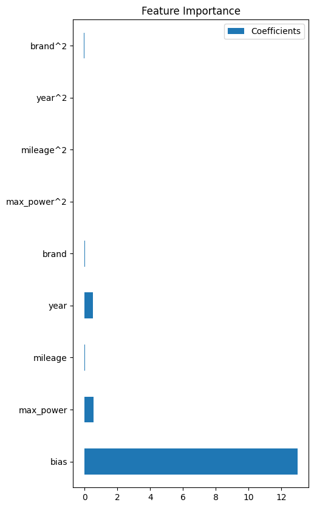

```python
model.feature_importance()
```

# Inference

Comparing the newly created model with the old model

```python
import pickle

filename = 'model/A2_car_prediction.model'
pickle.dump(model, open(filename, 'wb'))

scaler_path = 'model/A2_prediction_scalar.model'
pickle.dump(scaler, open(scaler_path, 'wb'))

label_path = 'model/A2_brand-label.model'
pickle.dump(original_brands, open(label_path, 'wb'))
```

```python
new_model_path = 'model/A2_car_prediction.model'
new_scalar_path = 'model/A2_prediction_scalar.model'
new_brand_path = 'model/A2_brand-label.model'

#Loading components
new_model = pickle.load(open(new_model_path, 'rb'))
new_scalar = pickle.load(open(new_scalar_path, 'rb'))
new_brand = pickle.load(open(new_brand_path, 'rb'))

#For the old model
old_model_path = 'model/old_car_prediction.model'
old_scalar_path = 'model/old_prediction_scalar.model'
old_brand_path = 'model/old_brand-label.model'

old_model = pickle.load(open(old_model_path, 'rb'))
old_scalar = pickle.load(open(old_scalar_path, 'rb'))
old_brand = pickle.load(open(old_brand_path, 'rb'))
```

```python
old_y_pred = old_model.predict(X_test)
print(f"Predicted old model selling price: {np.exp(old_model.predict(X_test)[56])}")
new_y_pred = new_model.predict(X_test)
print(f"Predicted new model selling price: {np.exp(new_model.predict(X_test)[56])}")
```

```
Predicted old model selling price: 1181972.4139687722
Predicted new model selling price: 1046775.3576793356
```